# R Notebook

[figure not shown]

# Introducción

# Relevancia

Ahora que hemos vuelto a la presencialidad , es de gran importancia conocer cuales son las medidas de bioseguridad que los estudiantes de la UTEC siguen manteniendo dentro de las instalaciones de la universidad, cuales se están dejando de practicar paulatinamente y cuales ya no se realizan, teniendo en cuenta que algunas ya son opcionales según decreto supremo N° 108-2022-PCM, así que la decisión de garantizar un ambiente estudiantil seguro es responsabilidad de todos .

**Objetivo general:**

Identificar las medidas de bioseguridad que los estudiantes de la UTEC practican, mediante un análisis estadístico para medir la frecuencia en que lo realizan

**Objetivos específicos :**

-Realizar una estimación de cuantas medidas de bioseguridad siguen practicando los estudiantes de la UTEC.

-Conocer el grado de seguridad de de los estudiantes respecto a la prevención del COVID-19 en los espacios dentro de la universidad.

-Utilizar descriptores estadísticos para determinar de manera precisa la relación entre variables.

# Planificación

```r
library(readr)
library(dplyr)
```

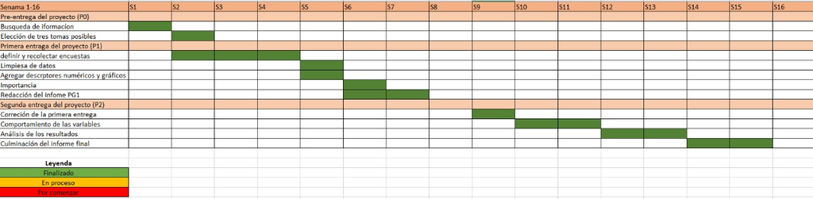

```r
library(ggplot2)
library(ggthemes)
library(modeest)
```

# Datos

# Recolección de datos

Para la realización de este trabajo estadístico recolectamos nuestros datos mediante una encuesta creada en Google Forms, el cual contaba con preguntas puntuales relacionadas a las variables, además la mayoría fueron con opciones para evitar que se ingresen datos erróneos o atípicos y se realizara más rápido.

Para tener un mayor alcance cada uno de los integrantes de este grupo salimos a encuestar en puntos concurridos de la universidad y compartimos nuestro link por grupos masivos de Whatsapp y Telegram en la que se encontraban estudiantes de la UTEC, además par dar un incentivo decidimos realizar un sorteo dirigido a todos los que llenaran la encuesta.

# Población, Muestra, Muestreo

**Población:**

Nuestra población de estudio fueron los estudiantes de pregrado de la Universidad de Ingeniería y Tecnología (UTEC) de todas las carreras y ciclos.

**Muestra:**

El tamaño de nuestra muestra fue de 211 observaciones

**Muestreo:**

El tipo de muestreo que realizamos para este estudio es *muestreo aleatorio simple*, se determinó esto porque cada alumno de UTEC que pertenece a nuestra muestra tiene la misma probabilidad de ser seleccionado. Debemos recalcar que a pesar de los esfuerzos consideramos que nuestra muestra **no es representativa**, pero nos acercamos a ella.

# Variables

[output not shown]

# Limpieza de datos

Una vez instalada la librería `readr` y la librería `dplyr`, lo que haremos es llamar a las librerías usando las funciones.

```r
library(readr)
library(dplyr)
```

Cargamos librerías adicionales

```r
library(stringr)
```

```r
library(ggplot2)
library(stringr)
library (FinCal)
library (hexbin)
```

Ahora que las librerías estén llamadas, estás nos ayudaran a poder leer nuestra tabla de datos, a esta tabla que será leída la llamaremos DB —> que significará datos bioseguridad

```r
DB <- read_csv(file = "Medidas.csv")
```

```
## , Cantidad de veces que se ...
##
```

Una vez incorporada la tabla y asignada al Rstudio dentro de nuestra variable, la llamamos, para un mejor panorama también usaremos `head` y `tail` para poder observar las 6 y ultimas filas de nuestra tabla.

```r
DB
```

```
## # A tibble: 211 x 20
##    `Marca temporal`   `Dirección de correo electrónico` `Nombres y apellidos`
##    <chr>              <chr>                             <chr>
##  1 9/24/2022 13:58:55 liliam.sandoval@utec.edu.pe       Liliam Sandoval Zapata
##  2 9/24/2022 14:02:44 abrahan.ypanaque@utec.edu.pe      Abrahan Orlando Ypanaqu~
##  3 9/24/2022 14:29:40 sergio.salvatierra@utec.edu.pe    Sergio Salvatierra Ñavi~
##  4 9/24/2022 14:35:05 daniela.tito@utec.edu.pe          Daniela Romina Tito Bus~
##  5 9/24/2022 15:02:38 dai.calisaya@utec.edu.pe          Dai Isabel Calisaya Del~
##  6 9/24/2022 15:27:05 kelly.cruz@utec.edu.pe            Kelly Marita Cruz Inga
##  7 9/24/2022 15:58:32 aldair.seminario@utec.edu.pe      Aldair Seminario Sánchez
##  8 9/24/2022 16:42:42 irma.chavez@utec.edu.pe           Irma Gaudencia Chavez G~
##  9 9/24/2022 17:20:04 gonzalo.sarmiento@utec.edu.pe     Gonzalo Edison Sarmient~
## 10 9/24/2022 18:20:43 conrad.leon@utec.edu.pe           Conrad Sebastian León C~
## # i 201 more rows
## # i 17 more variables: `¿En qué ciclo te encuentras actualmente?` <chr>,
## #   Carrera <chr>, Edad <dbl>,
## #   `¿Qué medidas bioseguridad usas para evitar contagiarte de Covid - 19 dentro de UTEC?` <chr>,
## #   `¿Llevas alcohol en gel al salir?\n` <dbl>,
## #   `Cantidad de veces que se lava las manos al día (Ej: 4)` <dbl>,
## #   `¿Con qué frecuencia sueles desechar tu mascarilla a la semana?` <dbl>, ...
```

```r
head(DB)#Está función nos ayudará para visualizar las 6 primeras filas
```

```
## # A tibble: 6 x 20
##   `Marca temporal`   `Dirección de correo electrónico` `Nombres y apellidos`
##   <chr>              <chr>                             <chr>
## 1 9/24/2022 13:58:55 liliam.sandoval@utec.edu.pe       Liliam Sandoval Zapata
## 2 9/24/2022 14:02:44 abrahan.ypanaque@utec.edu.pe      Abrahan Orlando Ypanaqué~
## 3 9/24/2022 14:29:40 sergio.salvatierra@utec.edu.pe    Sergio Salvatierra Ñavin~
## 4 9/24/2022 14:35:05 daniela.tito@utec.edu.pe          Daniela Romina Tito Bust~
## 5 9/24/2022 15:02:38 dai.calisaya@utec.edu.pe          Dai Isabel Calisaya Delg~
## 6 9/24/2022 15:27:05 kelly.cruz@utec.edu.pe            Kelly Marita Cruz Inga
## # i 17 more variables: `¿En qué ciclo te encuentras actualmente?` <chr>,
## #   Carrera <chr>, Edad <dbl>,
## #   `¿Qué medidas bioseguridad usas para evitar contagiarte de Covid - 19 dentro de UTEC?` <chr>,
## #   `¿Llevas alcohol en gel al salir?\n` <dbl>,
## #   `Cantidad de veces que se lava las manos al día (Ej: 4)` <dbl>,
## #   `¿Con qué frecuencia sueles desechar tu mascarilla a la semana?` <dbl>,
## #   `Cantidad de veces al día que utiliza los dispensadores de alcohol en gel ubicado en los distintos espacios de la UTEC` <dbl>, ...
```

```r
tail(DB)#Está función nos ayudará para visualizar las 6 ultimas filas
```

```
## # A tibble: 6 x 20
##   `Marca temporal`   `Dirección de correo electrónico` `Nombres y apellidos`
##   <chr>              <chr>                             <chr>
## 1 9/28/2022 18:11:15 marian.montalvo@utec.edu.pe       Marian Ariadne Montalvo ~
## 2 9/28/2022 18:54:19 santiago.madariaga@utec.edu.pe    Santiago Madariaga Colla~
## 3 9/28/2022 19:59:54 jefferson.huairi@utec.edu.pe      Jefferson Aldair Huairi ~
## 4 9/28/2022 20:55:19 edilson.polo@utec.edu.pe          Edilson Josep Polo Ponce
## 5 9/29/2022 0:01:53  viviana.chacchi.g@utec.edu.pe     Viviana Chacchi
## 6 9/29/2022 9:40:20  raul.velasquez@utec.edu.pe        Raul Roger Velasquez Med~
## # i 17 more variables: `¿En qué ciclo te encuentras actualmente?` <chr>,
## #   Carrera <chr>, Edad <dbl>,
## #   `¿Qué medidas bioseguridad usas para evitar contagiarte de Covid - 19 dentro de UTEC?` <chr>,
## #   `¿Llevas alcohol en gel al salir?\n` <dbl>,
## #   `Cantidad de veces que se lava las manos al día (Ej: 4)` <dbl>,
## #   `¿Con qué frecuencia sueles desechar tu mascarilla a la semana?` <dbl>,
## #   `Cantidad de veces al día que utiliza los dispensadores de alcohol en gel ubicado en los distintos espacios de la UTEC` <dbl>, ...
```

Usaremos `ncol` que sirve para ver el numero de variables (columnas) y `nrow` para conocer las observaciones(la cantidad de filas)

```r
ncol(DB)
```

```
## [1] 20
```

```r
nrow(DB)
```

```
## [1] 211
```

Usando `names` conoceremos dichas variables, Ahora que tenemos nuestras variables a la vista, existen variables que no son son relevantes para nuestro estudio estadístico, entonces las eliminaremos, por ejemplo: `Marca temporal` , `Dirección de correo electrónico` y `Nombres y apellidos`.

```r
names(DB)
```

```
##  [1] "Marca temporal"
##  [2] "Dirección de correo electrónico"
##  [3] "Nombres y apellidos"
##  [4] "¿En qué ciclo te encuentras actualmente?"
##  [5] "Carrera"
##  [6] "Edad"
##  [7] "¿Qué medidas bioseguridad usas para evitar contagiarte de Covid - 19 dentro de UTEC?"
##  [8] "¿Llevas alcohol en gel al salir?\n"
##  [9] "Cantidad de veces que se lava las manos al día (Ej: 4)"
## [10] "¿Con qué frecuencia sueles desechar tu mascarilla a la semana?"
## [11] "Cantidad de veces al día que utiliza los dispensadores de alcohol en gel ubicado en los distintos espacios de la UTEC"
## [12] "¿Sueles quitarte la mascarilla dentro del campus? Recuerda que ahora es opcional."
## [13] "¿Cuántas dosis de la vacuna contra el Covid-19 tienes?\nhttps://carnetvacunacion.minsa.gob.pe/#/auth (Mediante este link puedes acceder a tu carnet de vacunación)\n"
## [14] "¿Te has contagiado de COVID-19 anteriormente?"
## [15] "¿Cuántas veces has tenido Covid-19? (Comprobado mediante prueba)"
## [16] "Durante tus clases presenciales ¿Suelen tener el aula ventilada?"
## [17] "¿Cuántas medidas de bioseguridad encontraste en la universidad (UTEC) ?"
## [18] "¿Consideras que dentro de la universidad hay espacios de riesgo de contagio?"
## [19] "¿Qué espacios consideras que son propensos a contagios?"
## [20] "¿Que tiempo demoras lavandote las manos?"
```

Para poder descartar las variables mencionadas anteriormente usaremos `selec` y procedemos a escoger el rango de variables descartadas en este caso por ser contiguas, estás serán almacenadas en otra variable llamada **DA**.

```r
select(DB,-1:-3)->DA
DA
```

```
## # A tibble: 211 x 17
##    ¿En qué ciclo te encuentras actualment~1 Carrera  Edad ¿Qué medidas biosegu~2
##    <chr>                                    <chr>   <dbl> <chr>
##  1 Tercer ciclo                             Ingeni~    22 Utilizo los dispensad~
##  2 Tercer ciclo                             Ingeni~    18 Me lavo las mano vari~
##  3 Tercer ciclo                             Ingeni~    20 Utilizo los dispensad~
##  4 Tercer ciclo                             Ingeni~    20 Utilizo los dispensad~
##  5 Tercer ciclo                             Ingeni~    17 Utilizo los dispensad~
##  6 Tercer ciclo                             Ingeni~    19 Utilizo los dispensad~
##  7 Tercer ciclo                             Cienci~    18 Utilizo los dispensad~
##  8 Tercer ciclo                             Bioing~    19 Utilizo los dispensad~
##  9 Segundo ciclo                            Ingeni~    19 Utilizo los dispensad~
## 10 Quinto ciclo                             Ingeni~    20 Utilizo los dispensad~
## # i 201 more rows
## # i abbreviated names: 1: `¿En qué ciclo te encuentras actualmente?`,
## #   2: `¿Qué medidas bioseguridad usas para evitar contagiarte de Covid - 19 dentro de UTEC?`
## # i 13 more variables: `¿Llevas alcohol en gel al salir?\n` <dbl>,
## #   `Cantidad de veces que se lava las manos al día (Ej: 4)` <dbl>,
## #   `¿Con qué frecuencia sueles desechar tu mascarilla a la semana?` <dbl>,
## #   `Cantidad de veces al día que utiliza los dispensadores de alcohol en gel ubicado en los distintos espacios de la UTEC` <dbl>, ...
```

**Renombramos** las variables para facilitar el uso de estas mediante `rename`, estás nuevas variables serán guardadas en **DDHS** .

VARIABLES:

- Ciclo = ‘¿En qué ciclo te encuentras actualmente?’
- Medidas=‘¿Qué medidas bioseguridad usas para evitar contagiarte de Covid - 19 dentro de UTEC?’, Alcohol=‘¿Llevas alcohol en gel al salir?’,
- Lavado=‘Cantidad de veces que se lava las manos al día (Ej: 4)’,
- Mascarilla=‘¿Con qué frecuencia sueles desechar tu mascarilla a la semana?’, Dispensadores=‘Cantidad de veces al día que utiliza - los dispensadores de alcohol en gel ubicado en los distintos espacios de la UTEC’,
- Quitarte=‘¿Sueles quitarte la mascarilla dentro del campus? Recuerda que ahora es opcional.’, Dosis= ‘¿Cuántas dosis de la vacuna contra el Covid-19 tienes?://carnetvacunacion.minsa.gob.pe/#/auth (Mediante este link puedes acceder a tu carnet de vacunación)’, Contagiado=‘¿Te has contagiado de COVID-19 anteriormente?’, Num_covid=‘¿Cuántas veces has tenido Covid-19? (Comprobado mediante prueba)’, Ventilada=‘Durante tus clases presenciales ¿Suelen tener el aula ventilada?’, Num_medidas=‘¿Cuántas medidas de bioseguridad encontraste en la universidad (UTEC) ?’, Riesgo=‘¿Consideras que dentro de la universidad hay espacios de riesgo de contagio?’, Espacios=‘¿Qué espacios consideras que son propensos a contagios?’ )->DDHS

```r
rename(DA,Ciclo = '¿En qué ciclo te encuentras actualmente?', Medidas='¿Qué medidas bioseguridad usas para evitar contagiarte de Covid - 19 dentro de UTEC?', Alcohol='¿Llevas alcohol en gel al salir?
', Lavado='Cantidad de veces que se lava las manos al día (Ej: 4)', Mascarilla='¿Con qué frecuencia sueles desechar tu mascarilla a la semana?', Dispensadores='Cantidad de veces al día que utiliza los dispensadores de alcohol en gel ubicado en los distintos espacios de la UTEC', Quitarte='¿Sueles quitarte la mascarilla dentro del campus? Recuerda que ahora es opcional.', Dosis= '¿Cuántas dosis de la vacuna contra el Covid-19 tienes?\nhttps://carnetvacunacion.minsa.gob.pe/#/auth (Mediante este link puedes acceder a tu carnet de vacunación)\n', Contagiado='¿Te has contagiado de COVID-19 anteriormente?', Num_covid='¿Cuántas veces has tenido Covid-19? (Comprobado mediante prueba)', Ventilada='Durante tus clases presenciales ¿Suelen tener el aula ventilada?', Num_medidas='¿Cuántas medidas de bioseguridad encontraste en la universidad (UTEC) ?', Riesgo='¿Consideras que dentro de la universidad hay espacios de riesgo de contagio?', Espacios='¿Qué espacios consideras que son propensos a contagios?',Tiempo='¿Que tiempo demoras lavandote las manos?' )->DDHS

DDHS
```

```
## # A tibble: 211 x 17
##    Ciclo  Carrera  Edad Medidas Alcohol Lavado Mascarilla Dispensadores Quitarte
##    <chr>  <chr>   <dbl> <chr>     <dbl>  <dbl>      <dbl>         <dbl>    <dbl>
##  1 Terce~ Ingeni~    22 Utiliz~       1      1          9             2        2
##  2 Terce~ Ingeni~    18 Me lav~       1      4          4             0        2
##  3 Terce~ Ingeni~    20 Utiliz~       2      1          6             1        1
##  4 Terce~ Ingeni~    20 Utiliz~       1      4          3             1        2
##  5 Terce~ Ingeni~    17 Utiliz~       2      5          1             1        2
##  6 Terce~ Ingeni~    19 Utiliz~       2      5          1             2        2
##  7 Terce~ Cienci~    18 Utiliz~       2      7          3             2        2
##  8 Terce~ Bioing~    19 Utiliz~       2      8          1             0        1
##  9 Segun~ Ingeni~    19 Utiliz~       2      6          3             2        2
## 10 Quint~ Ingeni~    20 Utiliz~       2      5          8             4        1
## # i 201 more rows
## # i 8 more variables: Dosis <dbl>, Contagiado <chr>, Num_covid <dbl>,
## #   Ventilada <chr>, Num_medidas <dbl>, Riesgo <chr>, Espacios <chr>,
## #   Tiempo <dbl>
```

### DataFrame(implementacion y descarte de variables)

Una vez llamamos a nuestra nueva y actualizada data frame (DDHS) se aprecia el cambio de variables correctamente.

Para categorizar nuestras variables nos podemos apoyar mediante funciones de **R** como `str`, luego a `spec`, incluso con líneas de código.

```r
str(DDHS)
```

```
## tibble [211 x 17] (S3: tbl_df/tbl/data.frame)
##  $ Ciclo        : chr [1:211] "Tercer ciclo" "Tercer ciclo" "Tercer ciclo" "Tercer ciclo" ...
##  $ Carrera      : chr [1:211] "Ingeniería Electrónica" "Ingeniería Electrónica" "Ingeniería Civil" "Ingeniería Electrónica" ...
##  $ Edad         : num [1:211] 22 18 20 20 17 19 18 19 19 20 ...
##  $ Medidas      : chr [1:211] "Utilizo los dispensadores de alcohol en gel, Me lavo las mano varias veces al día, Uso de mascarilla" "Me lavo las mano varias veces al día, Uso de mascarilla" "Utilizo los dispensadores de alcohol en gel, Uso de mascarilla" "Utilizo los dispensadores de alcohol en …
##  $ Alcohol      : num [1:211] 1 1 2 1 2 2 2 2 2 2 ...
##  $ Lavado       : num [1:211] 1 4 1 4 5 5 7 8 6 5 ...
##  $ Mascarilla   : num [1:211] 9 4 6 3 1 1 3 1 3 8 ...
##  $ Dispensadores: num [1:211] 2 0 1 1 1 2 2 0 2 4 ...
##  $ Quitarte     : num [1:211] 2 2 1 2 2 2 2 1 2 1 ...
##  $ Dosis        : num [1:211] 3 3 3 3 3 3 3 3 3 4 ...
##  $ Contagiado   : chr [1:211] "Sí" "Sí" "No" "Sí" ...
##  $ Num_covid    : num [1:211] 1 1 2 1 0 1 0 0 0 1 ...
##  $ Ventilada    : chr [1:211] "Si" "Si" "Si" "Si" ...
##  $ Num_medidas  : num [1:211] 3 3 2 2 2 3 3 3 1 3 ...
##  $ Riesgo       : chr [1:211] "No" "Sí" "No" "No" ...
##  $ Espacios     : chr [1:211] NA "Ascensor" NA NA ...
##  $ Tiempo       : num [1:211] 3 13 2 8 10 15 21 24 6 15 ...
```

```r
unique(DDHS$Num_medidas)
```

```
## [1] 3 2 1 4
```

```r
unique(DDHS$Alcohol)
```

```
## [1] 1 2 3
```

```r
unique(DDHS$Quitarte)
```

```
## [1] 2 1 3
```

```r
spec(DDHS)
```

```r
tipos =  DDHS%>% sapply(class) %>% as.data.frame() %>% rename(tipo = 1)
tipos
```

```
##                    tipo
## Ciclo         character
## Carrera       character
## Edad            numeric
## Medidas       character
## Alcohol         numeric
## Lavado          numeric
## Mascarilla      numeric
## Dispensadores   numeric
## Quitarte        numeric
## Dosis           numeric
## Contagiado    character
## Num_covid       numeric
## Ventilada     character
## Num_medidas     numeric
## Riesgo        character
## Espacios      character
## Tiempo          numeric
```

Seleccionamos las columnas tipo factor .Un factor es una variable categórica con número finito de valores o niveles

```r
numeCol <- c("Edad", "Lavado", "Mascarilla", "Dispensadores", "Dosis", "Num_covid", "Num_medidas","Tiempo")
facCol <- names(DDHS)[!names(DDHS) %in% numeCol]
DDHS[facCol] <- lapply(DDHS[facCol],FUN =factor)
str(DDHS)
```

```
## tibble [211 x 17] (S3: tbl_df/tbl/data.frame)
##  $ Ciclo        : Factor w/ 10 levels "Cuarto ciclo",..: 10 10 10 10 10 10 10 10 7 6 ...
##  $ Carrera      : Factor w/ 12 levels "Administración y negocios digitales",..: 8 8 6 8 9 10 4 2 11 6 ...
##  $ Edad         : num [1:211] 22 18 20 20 17 19 18 19 19 20 ...
##  $ Medidas      : Factor w/ 19 levels ".","Evito conglomerados",..: 16 5 18 17 17 16 18 17 16 17 ...
##  $ Alcohol      : Factor w/ 3 levels "1","2","3": 1 1 2 1 2 2 2 2 2 2 ...
##  $ Lavado       : num [1:211] 1 4 1 4 5 5 7 8 6 5 ...
##  $ Mascarilla   : num [1:211] 9 4 6 3 1 1 3 1 3 8 ...
##  $ Dispensadores: num [1:211] 2 0 1 1 1 2 2 0 2 4 ...
##  $ Quitarte     : Factor w/ 3 levels "1","2","3": 2 2 1 2 2 2 2 1 2 1 ...
##  $ Dosis        : num [1:211] 3 3 3 3 3 3 3 3 3 4 ...
##  $ Contagiado   : Factor w/ 3 levels "No","No lo sé",..: 3 3 1 3 1 3 1 2 2 3 ...
##  $ Num_covid    : num [1:211] 1 1 2 1 0 1 0 0 0 1 ...
##  $ Ventilada    : Factor w/ 3 levels "A veces","No",..: 3 3 3 3 3 3 3 3 1 3 ...
##  $ Num_medidas  : num [1:211] 3 3 2 2 2 3 3 3 1 3 ...
##  $ Riesgo       : Factor w/ 2 levels "No","Sí": 1 2 1 1 2 2 2 1 1 2 ...
##  $ Espacios     : Factor w/ 14 levels "Ascensor","Ascensor, Aula sin ventilación",..: NA 1 NA NA 7 1 1 NA NA 8 ...
##  $ Tiempo       : num [1:211] 3 13 2 8 10 15 21 24 6 15 ...
```

```r
numéricas <- length(select_if(DDHS, is.numeric)) #cantidad de variables numéricas (length mide la cantidad de un vector)
numéricas
```

```
## [1] 8
```

```r
categóricas <-length(DDHS)-numéricas
categóricas
```

```
## [1] 9
```

Ahora que nuestras variables están categorizadas y renombradas buscaremos si existen datos faltantes en nuestro data frame(*DDHS*), esto mediante `sum` y `is.na`.

```r
sum(is.na(DDHS))
```

```
## [1] 81
```

```r
summary(DDHS)
```

```
##            Ciclo                         Carrera        Edad
##  Tercer ciclo :91   Ingeniería Industrial    :40   Min.   :17.00
##  Cuarto ciclo :31   Ingeniería Civil         :32   1st Qu.:18.00
##  Segundo ciclo:27   Ingeniería Mecatrónica   :28   Median :19.00
##  Primer ciclo :21   Bioingeniería            :24   Mean   :19.18
##  Sexto ciclo  :13   Ingeniería Electrónica   :19   3rd Qu.:20.00
##  Quinto ciclo :10   Ciencia de la computación:17   Max.   :26.00
##  (Other)      :18   (Other)                  :51
##                                                                                                                       Medidas
##  Me lavo las mano varias veces al día, Uso de mascarilla                                                                  :44
##  Utilizo los dispensadores de alcohol en gel, Me lavo las mano varias veces al día, Uso de mascarilla                     :35
##  Utilizo los dispensadores de alcohol en gel, Me lavo las mano varias veces al día, Uso de mascarilla, Evito conglomerados:28
##  Utilizo los dispensadores de alcohol en gel, Uso de mascarilla                                                           :25
##  Uso de mascarilla                                                                                                        :22
##  Uso de mascarilla, Evito conglomerados                                                                                   : 9
##  (Other)                                                                                                                  :48
##  Alcohol     Lavado         Mascarilla    Dispensadores   Quitarte
##  1:84    Min.   : 1.000   Min.   :1.000   Min.   :0.000   1: 28
##  2:92    1st Qu.: 4.000   1st Qu.:1.000   1st Qu.:1.000   2:121
##  3:35    Median : 6.000   Median :2.000   Median :2.000   3: 62
##          Mean   : 5.716   Mean   :2.867   Mean   :1.621
##          3rd Qu.: 7.000   3rd Qu.:4.000   3rd Qu.:2.500
##          Max.   :10.000   Max.   :9.000   Max.   :5.000
##
##      Dosis          Contagiado    Num_covid        Ventilada    Num_medidas
##  Min.   :0.000   No      : 61   Min.   :0.0000   A veces: 60   Min.   :1.000
##  1st Qu.:3.000   No lo sé: 47   1st Qu.:0.0000   No     : 10   1st Qu.:2.000
##  Median :3.000   Sí      :103   Median :1.0000   Si     :140   Median :3.000
##  Mean   :2.976                  Mean   :0.7346   NA's   :  1   Mean   :2.517
##  3rd Qu.:3.000                  3rd Qu.:1.0000                 3rd Qu.:3.000
##  Max.   :4.000                  Max.   :3.0000                 Max.   :4.000
##
##  Riesgo                                                Espacios      Tiempo
##  No: 80   Ascensor, Comedor                                :24   Min.   : 2.0
##  Sí:131   Ascensor, Aula sin ventilación                   :18   1st Qu.:12.0
##           Ascensor, Comedor, Aula sin ventilación          :16   Median :16.0
##           Ascensor, Cubículo, Comedor, Aula sin ventilación:15   Mean   :16.1
##           Ascensor                                         :13   3rd Qu.:21.0
##           (Other)                                          :45   Max.   :30.0
##           NA's                                             :80
```

Observamos que tenemos **81** datos faltantes

Ahora si queremos saber la cantidad de datos incompletos y completos lo podemos hacer mediante `complete.cases` y su respectiva negación.

```r
datos_c <- sum(complete.cases(DDHS))
datos_i <- sum(!complete.cases(DDHS))
datos_c
```

```
## [1] 130
```

```r
datos_i
```

```
## [1] 81
```

### Ciclo

```r
table(DDHS$Ciclo)
```

```
##
##  Cuarto ciclo  Décimo ciclo  Noveno ciclo  Octavo ciclo  Primer ciclo
##            31             2             3             7            21
##  Quinto ciclo Segundo ciclo Séptimo ciclo   Sexto ciclo  Tercer ciclo
##            10            27             6            13            91
```

Como podemos apreciar los ciclos están desordenados, no existen datos atípicos ni tampoco datos faltantes. Solo necesitaríamos el orden.

```r
table(factor(DDHS$Ciclo, levels = c("Primer ciclo", "Segundo ciclo", "Tercer ciclo", "Cuarto ciclo", "Quinto ciclo", "Sexto ciclo", "Séptimo ciclo", "Octavo ciclo", "Noveno ciclo", "Décimo ciclo"), ordered = TRUE))
```

```
##
##  Primer ciclo Segundo ciclo  Tercer ciclo  Cuarto ciclo  Quinto ciclo
##            21            27            91            31            10
##   Sexto ciclo Séptimo ciclo  Octavo ciclo  Noveno ciclo  Décimo ciclo
##            13             6             7             3             2
```

Ya tenemos ordenado nuestros ciclos.

### Carrera

```r
table(DDHS$Carrera)
```

```
##
## Administración y negocios digitales                       Bioingeniería
##                                  13                                  24
##                    Ciencia de datos           Ciencia de la computación
##                                   2                                  17
##                Ingeniería Ambiental                    Ingeniería Civil
##                                  11                                  32
##            Ingeniería De la energía              Ingeniería Electrónica
##                                   5                                  19
##               Ingeniería Industrial                 Ingeniería Mecánica
##                                  40                                   8
##              Ingeniería Mecatrónica                  Ingeniería Quìmica
##                                  28                                  12
```

En nuestra encuesta existía la opción de marcar tu carrera, por ende no existe respuestas propensas al mal formato o diferentes caracteres.

### Edad

```r
table(DDHS$Edad)
```

```
##
## 17 18 19 20 21 22 23 24 25 26
## 24 55 65 35 11 11  5  1  3  1
```

Si queremos revisar la existencia de datos faltantes…

```r
sum(is.na(DDHS$Edad))
```

```
## [1] 0
```

Tenemos 0 datos faltantes y con edades que corresponden de cierta manera o no se prestan como **Datos Atípicos**, esta explicación se va a ver de mejor manera en el Diagrama de Caja y bigotes en el próximo slide.

### Alcohol

Como tenemos valores numerarios que representan frecuencia de uso de alcohol en gel, sería conveniente describirla de mejor manera literalmente.

```r
table(DDHS$Alcohol)
```

```
##
##  1  2  3
## 84 92 35
```

Esta limpieza es **AGRESIVA**.

Veamos una limpieza menos agresiva

Revisen las funciones `grep` y `gsub`.

```r
? gsub
```

```
## starting httpd help server ... done
```

```r
? grep
```

```r
DDHS$Alcohol <- gsub(1, "Nunca", DDHS$Alcohol)
DDHS$Alcohol <- gsub(2, "A veces", DDHS$Alcohol)
DDHS$Alcohol <- gsub(3, "Siempre", DDHS$Alcohol)
```

```r
DDHS$Alcohol
```

```
##   [1] "Nunca"   "Nunca"   "A veces" "Nunca"   "A veces" "A veces" "A veces"
##   [8] "A veces" "A veces" "A veces" "Siempre" "Siempre" "Nunca"   "Nunca"
##  [15] "Nunca"   "A veces" "A veces" "A veces" "Siempre" "A veces" "A veces"
##  [22] "Siempre" "A veces" "Nunca"   "Nunca"   "Siempre" "A veces" "A veces"
##  [29] "A veces" "Siempre" "Siempre" "Nunca"   "Nunca"   "A veces" "A veces"
##  [36] "Nunca"   "Nunca"   "Nunca"   "Nunca"   "A veces" "Nunca"   "Siempre"
##  [43] "Nunca"   "Siempre" "Nunca"   "A veces" "A veces" "Nunca"   "Siempre"
##  [50] "A veces" "A veces" "Nunca"   "Nunca"   "Siempre" "A veces" "Siempre"
##  [57] "Nunca"   "A veces" "A veces" "A veces" "Nunca"   "Nunca"   "Nunca"
##  [64] "Siempre" "Siempre" "A veces" "Siempre" "A veces" "Nunca"   "Siempre"
##  [71] "A veces" "Nunca"   "A veces" "Nunca"   "Nunca"   "Nunca"   "A veces"
##  [78] "Nunca"   "A veces" "A veces" "Siempre" "Siempre" "A veces" "Nunca"
##  [85] "Siempre" "Siempre" "Nunca"   "Nunca"   "Nunca"   "A veces" "A veces"
##  [92] "A veces" "Siempre" "Nunca"   "Siempre" "Siempre" "Nunca"   "Siempre"
##  [99] "Nunca"   "Nunca"   "Nunca"   "Nunca"   "Nunca"   "Siempre" "A veces"
```

[output cut: 16 more lines]

Ahora ya están correctamente descritas.

### Lavado

```r
table(DDHS$Lavado)
```

```
##
##  1  2  3  4  5  6  7  8  9 10
##  6 12 17 27 31 41 30 24 16  7
```

### Mascarilla - ¿Con qué frecuencia sueles desechar tu mascarilla a la semana?

```r
table(DDHS$Mascarilla)
```

```
##
##  1  2  3  4  5  6  7  8  9
## 58 53 36 25 18 11  5  3  2
```

La base de datos para la variable `Mascarilla` se encuentra conforme y no encontramos nada fuera de la realidad.

### Dispensadores - Cantidad de veces al día que utiliza - los dispensadores de alcohol en gel ubicado en los distintos espacios de la UTEC

```r
table(DDHS$Dispensadores)
```

```
##
##  0  1  2  3  4  5
## 42 59 57 46  4  3
```

Los datos brindados por parte de los encuestados **no** se prestan para posibles malas interpretaciones, luego en el análisis descriptivo observaremos que en el diagrama de cajas las edades no están tan dispersas.

### Quitarte - ¿Sueles quitarte la mascarilla dentro del campus? Recuerda que ahora es opcional

```r
table(DDHS$Quitarte)
```

```
##
##   1   2   3
##  28 121  62
```

Observamos que existen valores numéricos, lo cual no es cierto pues estás son categóricas dado que representan intensidad, entonceslo que haremos es darle un formato literal para su mejor interpretación gráfico un próximo gráfico.

```r
DDHS$Quitarte <- gsub(1, "Nunca", DDHS$Quitarte)
DDHS$Quitarte <- gsub(2, "A veces", DDHS$Quitarte)
DDHS$Quitarte <- gsub(3, "Siempre", DDHS$Quitarte)
```

```r
DDHS$Quitarte
```

```
##   [1] "A veces" "A veces" "Nunca"   "A veces" "A veces" "A veces" "A veces"
##   [8] "Nunca"   "A veces" "Nunca"   "Nunca"   "Nunca"   "A veces" "Siempre"
##  [15] "Siempre" "A veces" "Nunca"   "Siempre" "Siempre" "Nunca"   "A veces"
##  [22] "A veces" "A veces" "Siempre" "A veces" "A veces" "A veces" "A veces"
##  [29] "A veces" "A veces" "A veces" "A veces" "A veces" "A veces" "A veces"
##  [36] "Siempre" "Siempre" "A veces" "Nunca"   "Siempre" "A veces" "A veces"
##  [43] "Nunca"   "A veces" "A veces" "A veces" "A veces" "Siempre" "A veces"
##  [50] "A veces" "Nunca"   "Nunca"   "A veces" "Siempre" "Siempre" "Siempre"
##  [57] "Siempre" "Nunca"   "A veces" "A veces" "Siempre" "Siempre" "Siempre"
##  [64] "Nunca"   "A veces" "A veces" "A veces" "A veces" "Siempre" "Siempre"
##  [71] "Nunca"   "A veces" "A veces" "A veces" "Siempre" "A veces" "Siempre"
##  [78] "A veces" "Siempre" "A veces" "Siempre" "A veces" "A veces" "Nunca"
##  [85] "A veces" "Nunca"   "A veces" "A veces" "A veces" "A veces" "Nunca"
##  [92] "A veces" "A veces" "A veces" "A veces" "Siempre" "Siempre" "Siempre"
##  [99] "Siempre" "Siempre" "Siempre" "A veces" "Siempre" "A veces" "A veces"
```

[output cut: 16 more lines]

### Dosis - ¿Cuántas dosis de la vacuna contra el Covid-19 tienes?

```r
table(DDHS$Dosis)
```

```
##
##   0   1   2   3   4
##   1   1  10 189  10
```

Los datos obtenidos son los mostrados, existen personas (1 persona) que aún no se ha vacunado, posiblemente porque no cree en las vacunas o que su cuerpo tenga algún tipo de rechazo hacia ellas, luego como máximo tenemos 4 vacunas que también está dentro del rango común y establecido por EsSalud.

Entonces estos datos que mencionan que se vacunaron 0, 1 y 2 veces a la fecha las consideraremos por el argumento mencionado anteriormente, Si bien la Universidad UTEC puso como restricción que se volvería a la presencialidad siempre y cuando el alumno presente su carné de vacunación con 3 dosis, creemos que estás fueron justificadas.

### Contagiado - ¿Te has contagiado de COVID-19 anteriormente?

```r
table(DDHS$Contagiado)
```

```
##
##       No No lo sé       Sí
##       61       47      103
```

### Num_covid - ¿Cuántas veces has tenido Covid-19? (Comprobado mediante prueba)

```r
table(DDHS$Num_covid)
```

```
##
##   0   1   2   3
## 102  66  40   3
```

### Ventilada - Durante tus clases presenciales ¿Suelen tener el aula ventilada?

```r
unique(DDHS$Ventilada)
```

```
## [1] Si      A veces No      <NA>
## Levels: A veces No Si
```

Se observa que existe un **NA** entonces no la optaremos.

### Num_medidas - ¿Cuántas medidas de bioseguridad encontraste en la universidad (UTEC) ?

```r
table(DDHS$Num_medidas)
```

```
##
##   1   2   3   4
##  12  79 119   1
```

### Riesgo - ¿Consideras que dentro de la universidad hay espacios de riesgo de contagio?

```r
table(DDHS$Riesgo)
```

```
##
##  No  Sí
##  80 131
```

### Espacios - ¿Qué espacios consideras que son propensos a contagios?

```r
unique(DDHS$Espacios)
```

```
##  [1] <NA>
##  [2] Ascensor
##  [3] Ascensor, Cubículo, Comedor
##  [4] Ascensor, Cubículo, Comedor, Aula sin ventilación
##  [5] Ascensor, Aula sin ventilación
##  [6] Ascensor, Comedor, Aula sin ventilación
##  [7] Ascensor, Comedor
##  [8] Comedor
##  [9] Ascensor, Cubículo, Aula sin ventilación
## [10] Comedor, Aula sin ventilación
## [11] Aula sin ventilación
## [12] Cubículo
## [13] Ascensor, Cubículo
## [14] Cubículo, Comedor
## [15] Cubículo, Aula sin ventilación
## 14 Levels: Ascensor Ascensor, Aula sin ventilación ... Cubículo, Comedor
```

# Análisis Descriptivo

# Descriptores Gráficos y Numéricos para una variable

**Categóricas**

**ciclo:**

Esta variable nos permitirá conocer si el nivel del ciclo influye en la responsabilidad de cuidado.

```r
table(factor(DDHS$Ciclo, levels = c("Primer ciclo", "Segundo ciclo", "Tercer ciclo", "Cuarto ciclo", "Quinto ciclo", "Sexto ciclo", "Séptimo ciclo", "Octavo ciclo", "Noveno ciclo", "Décimo ciclo"), ordered = TRUE))
```

```
##
##  Primer ciclo Segundo ciclo  Tercer ciclo  Cuarto ciclo  Quinto ciclo
##            21            27            91            31            10
##   Sexto ciclo Séptimo ciclo  Octavo ciclo  Noveno ciclo  Décimo ciclo
##            13             6             7             3             2
```

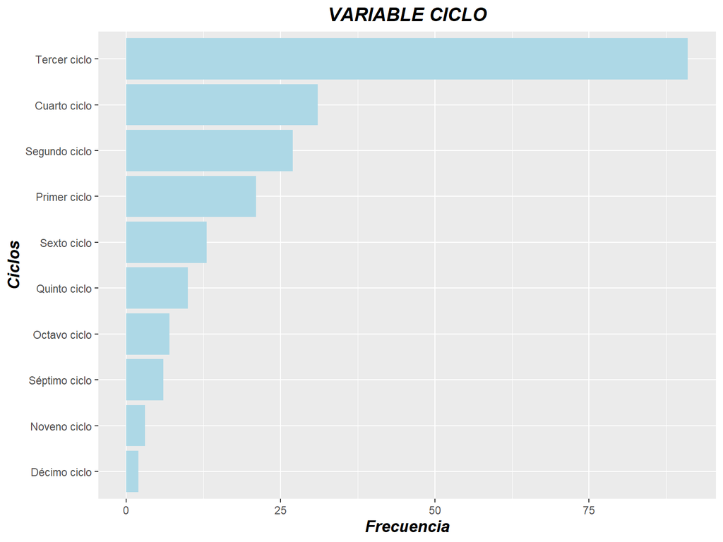

```r
ggplot(DDHS) +
  aes(x = reorder(Ciclo, Ciclo, function(x)+length(x))) +
  geom_bar(fill = "light blue") +
  labs(
    x = "Ciclos",
    y = "Frecuencia",
    title = "VARIABLE CICLO"
  ) +
  coord_flip() +
  theme_gray() +
  theme(
    plot.title = element_text(size = 15L,
    face = "bold.italic",
    hjust = 0.5),
    axis.title.y = element_text(size = 13L,
    face = "bold.italic"),
    axis.title.x = element_text(size = 13L,
    face = "bold.italic")
  )
```

Observamos que no hay ninguna anomalía con respecto a la variable de ciclo , solo que se encuentran menos encuestados en las de ciclo mayores y más encuestados en el ciclo 3.

**Carrera**

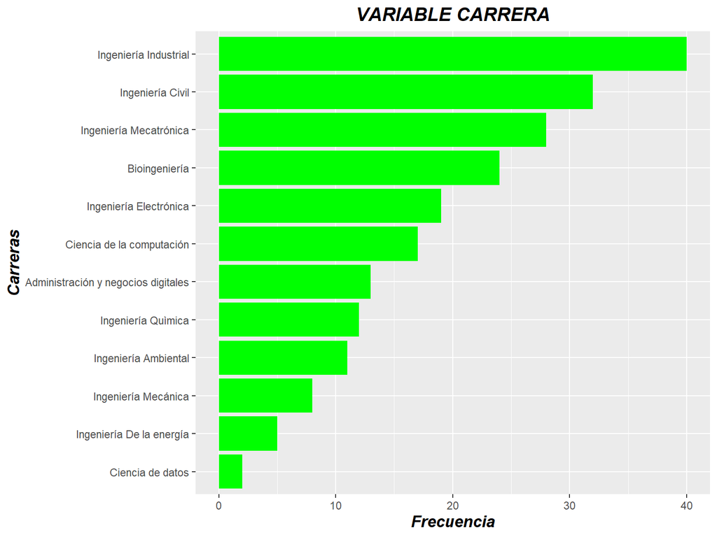

```r
ggplot(DDHS) +
  aes(x = reorder(Carrera, Carrera, function(x)+length(x))) +
  geom_bar(fill = "green") +
  labs(
    x = "Carreras",
    y = "Frecuencia",
    title = "VARIABLE CARRERA"
  ) +
  coord_flip() +
  theme_gray() +
  theme(
    plot.title = element_text(size = 15L,
    face = "bold.italic",
    hjust = 0.5),
    axis.title.y = element_text(size = 13L,
    face = "bold.italic"),
    axis.title.x = element_text(size = 13L,
    face = "bold.italic")
  )
```

```r
table(DDHS$Carrera)
```

```
##
## Administración y negocios digitales                       Bioingeniería
##                                  13                                  24
##                    Ciencia de datos           Ciencia de la computación
##                                   2                                  17
##                Ingeniería Ambiental                    Ingeniería Civil
##                                  11                                  32
##            Ingeniería De la energía              Ingeniería Electrónica
##                                   5                                  19
##               Ingeniería Industrial                 Ingeniería Mecánica
##                                  40                                   8
##              Ingeniería Mecatrónica                  Ingeniería Quìmica
##                                  28                                  12
```

Este gráfico de barras invertido nos muestra un resumen de la cantidad de alumnos por carrera en orden decreciente a fin de diferenciarlas, esta data fue corroborada por las oficinas de UTEC el cual dijeron que por ejemplo hay mayor cantidad de alumnos en Ingeniería Industrial e Ingeniería Civil.

MODA: Se aprecia que la carrera de Ingeniería Industrial es la que más se repite.

**Alcohol**

Esta variable nos permitirá conocer si suelen llevar alcohol en gel los estudiantes de UTEC.

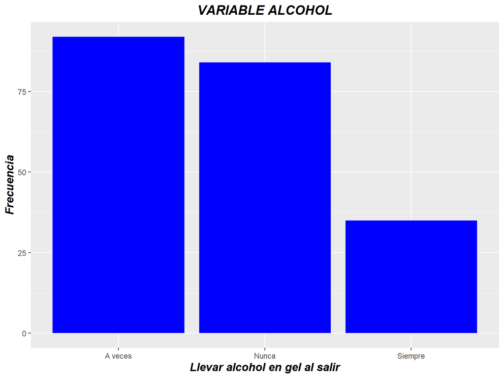

```r
ggplot(DDHS) +
  aes(x = reorder(Alcohol,Alcohol, function(x)-length(x))) +
  geom_bar(fill = "blue") +
  labs(
    x = "Llevar alcohol en gel al salir",
    y = "Frecuencia",
    title = "VARIABLE ALCOHOL"
  ) +
  theme_gray() +
  theme(
    plot.title = element_text(size = 15L,
    face = "bold.italic",
    hjust = 0.5),
    axis.title.y = element_text(size = 13L,
    face = "bold.italic"),
    axis.title.x = element_text(size = 13L,
    face = "bold.italic")
  )
```

```r
table(DDHS$Alcohol)
```

```
##
## A veces   Nunca Siempre
##      92      84      35
```

De esta gráfica podemos interpretar que la mayoría solo lleva a veces el alcohol en gel, y la minoría siempre lo realiza, es decir están dejando de practicar esta medida paulatinamente MODA: Se observa que el dato que más se repite es la respuesta “A veces”

**Quitarte mascarilla** Como sabemos a partir del 28 de agosto el gobierno oficializó el uso opcional de mascarillas para los estudiantes en las aulas, según lo establece el decreto supremo n° 108-2022-PCM, así que esta variable nos permitirá conocer si los Utecsinos ya están dejando paulatinamente esta medida, o si algunos a pesar de que sea opcional si desean seguir utilizando como una medida de prevención no solo del COVID-19 sino de otras enfermedades.

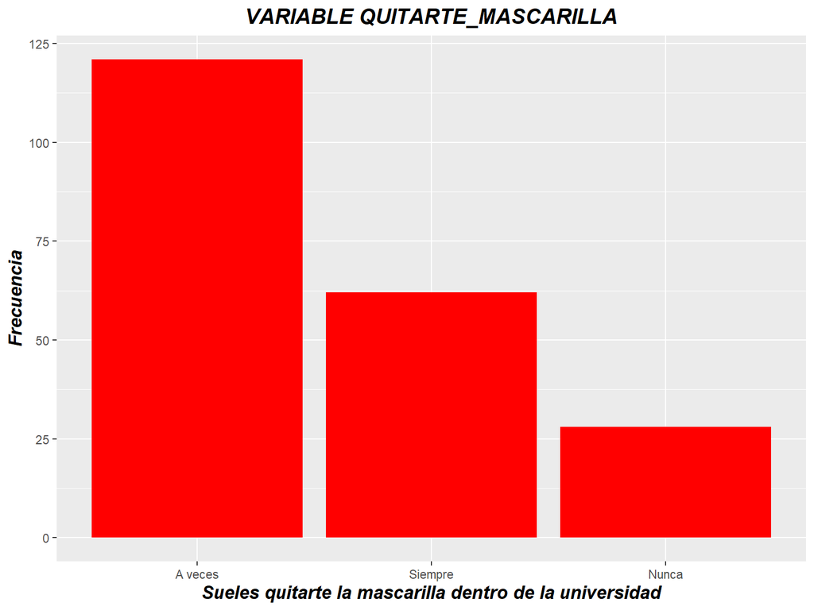

```r
ggplot(DDHS) +
  aes(x = reorder(Quitarte,Quitarte, function(x)-length(x))) +
  geom_bar(fill = "red") +
  labs(
    x = "Sueles quitarte la mascarilla dentro de la universidad",
    y = "Frecuencia",
    title = "VARIABLE QUITARTE_MASCARILLA"
  ) +
  theme_gray() +
  theme(
    plot.title = element_text(size = 15L,
    face = "bold.italic",
    hjust = 0.5),
    axis.title.y = element_text(size = 13L,
    face = "bold.italic"),
    axis.title.x = element_text(size = 13L,
    face = "bold.italic")
  )
```

**Contagiado**

Esta variable nos permitirá mapear la cantidad de Utecinos que se han contagiado

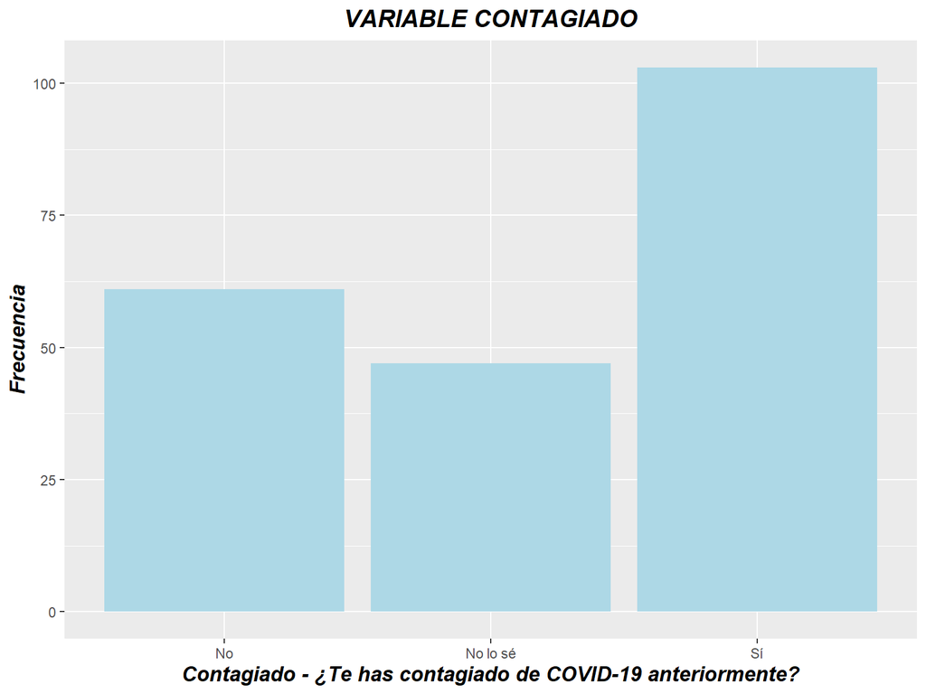

```r
ggplot(DDHS) +
  aes(x = Contagiado) +
  geom_bar(fill = "light blue") +
  labs(
    x = "Contagiado - ¿Te has contagiado de COVID-19 anteriormente?",
    y = "Frecuencia",
    title = "VARIABLE CONTAGIADO"
  ) +
  theme_gray() +
  theme(
    plot.title = element_text(size = 15L,
    face = "bold.italic",
    hjust = 0.5),
    axis.title.y = element_text(size = 13L,
    face = "bold.italic"),
    axis.title.x = element_text(size = 13L,
    face = "bold.italic")
  )
```

```r
table(DDHS$Contagiado)
```

```
##
##       No No lo sé       Sí
##       61       47      103
```

Este gráfico nos muestra la comparación de respuestas brindadas por parte de los alumnos UTEC acerca si ya han tenido Covid anteriormente, 103 personas respondieron que sí, 61 que no tuvieron COVID-19 y 47 que no sabían, entonces podemos deducir que la moda es la respuesta “sí”.

*Variables Numéricas*

**Edad:**

Esta variable se utilizó para verificar que se está cumpliendo y llegando con el público objetivo, para analizarlo se realizó una tabla de esa variable

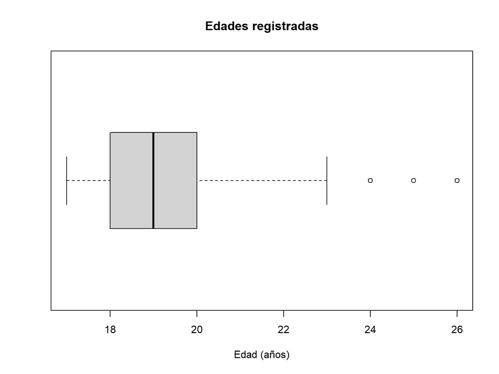

```r
boxplot(DDHS$Edad
        , main = "Edades registradas"
        , xlab = "Edad (años)"
        , horizontal = TRUE
        )
```

```r
#Descriptores de ubicación
round(mean(DDHS$Edad),2)
```

```
## [1] 19.18
```

```r
mfv(DDHS$Edad)
```

```
## [1] 19
```

```r
median(mean(DDHS$Edad))
```

```
## [1] 19.17536
```

```r
max(DDHS$Edad)
```

```
## [1] 26
```

```r
round(mean(DDHS$Edad[!DDHS$Edad%in% boxplot.stats(DDHS$Edad)$out],na.rm=T),2)
```

```
## [1] 19.03
```

**Dosis**

Esta variable se utilizó para poder saber la cantidad de veces que la persona se vacunó.

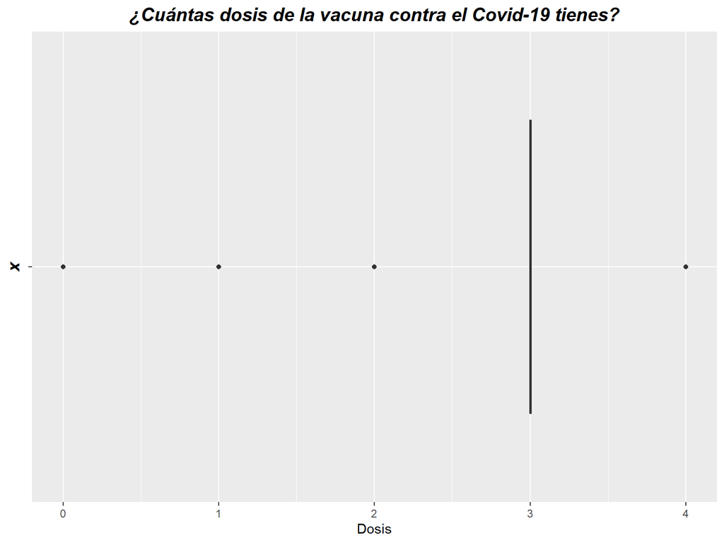

```r
ggplot(DDHS) +
  aes(x = "", y = as.numeric(Dosis)) +
  geom_boxplot(fill = "light blue") +
  labs(y = "Dosis", title = "¿Cuántas dosis de la vacuna contra el Covid-19 tienes?") +
  coord_flip() +
  theme_gray() +
  theme(
    plot.title = element_text(size = 15L,
    face = "bold.italic",
    hjust = 0.5),
    axis.title.y = element_text(size = 13L,
    face = "bold.italic")
  )
```

De la gráfica de caja se aprecia que en la gráfica de cajas y bigotes debido a que son 5 datos entonces solo tiene una mediana y según el gráfico es el numero **3**,

```r
round(mean(DDHS$Dosis),2)
```

```
## [1] 2.98
```

```r
mfv(DDHS$Dosis)
```

```
## [1] 3
```

```r
median(DDHS$Dosis)
```

```
## [1] 3
```

```r
round(mean(DDHS$Dosis[!DDHS$Dosis%in% boxplot.stats(DDHS$Dosis)$out],na.rm=T),2)
```

```
## [1] 3
```

**Lavado**

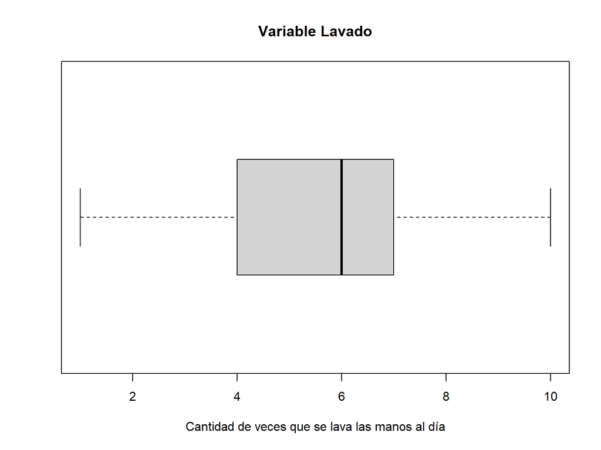

```r
boxplot(DDHS$Lavado
        , main = "Variable Lavado"
        , xlab = "Cantidad de veces que se lava las manos al día"
        , horizontal = TRUE
        )
```

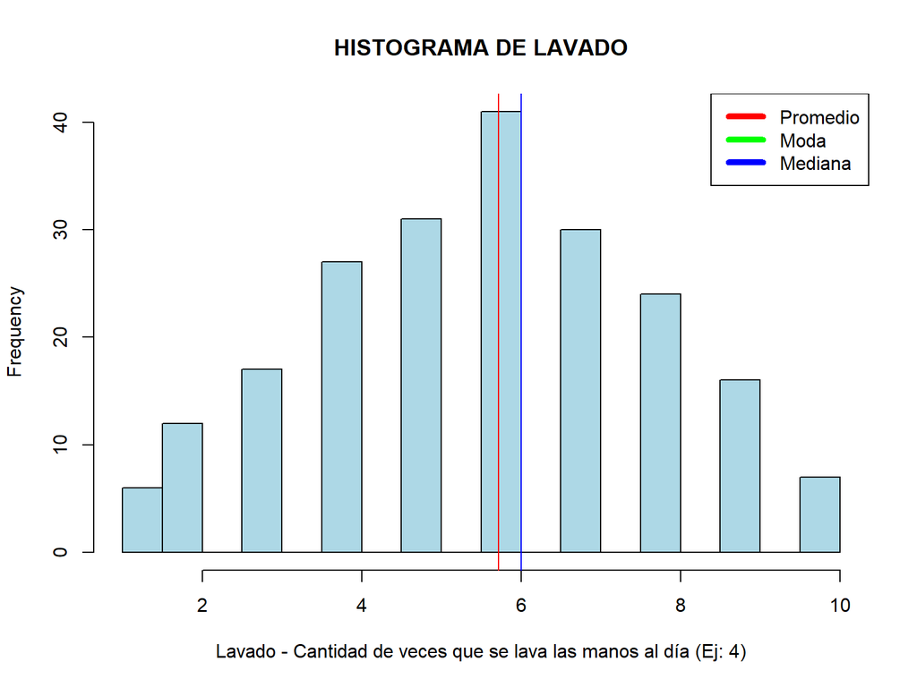

```r
library(modeest)
hist(DDHS$Lavado, xlab="Lavado - Cantidad de veces que se lava las manos al día (Ej: 4)", main="HISTOGRAMA DE LAVADO", breaks=15, col="light blue")
abline(v=mean(DDHS$Lavado),col="red")
abline(v=mfv(DDHS$Lavado),col="green")
abline(v=median(DDHS$Lavado),col="blue")
legend("topright", c("Promedio", "Moda","Mediana"), col=c("red", "green", "blue"), lty=1:1, lwd=5)
```

```r
round(mean(DDHS$Lavado),2)
```

```
## [1] 5.72
```

```r
mfv(DDHS$Lavado)
```

```
## [1] 6
```

```r
median(DDHS$Lavado)
```

```
## [1] 6
```

```r
round(mean(DDHS$Lavado[!DDHS$Lavado%in% boxplot.stats(DDHS$Lavado)$out],na.rm=T),2)
```

```
## [1] 5.72
```

**Mascarilla**

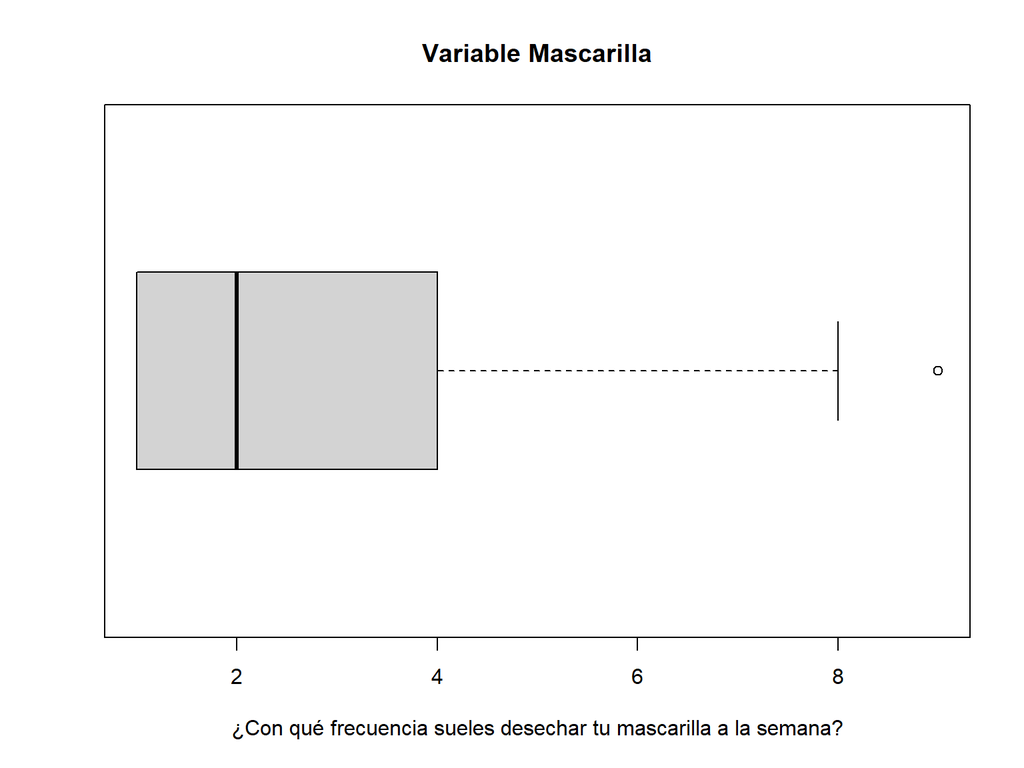

```r
boxplot(DDHS$Mascarilla
        , main = "Variable Mascarilla"
        , xlab = "¿Con qué frecuencia sueles desechar tu mascarilla a la semana?"
        , horizontal = TRUE
        )
```

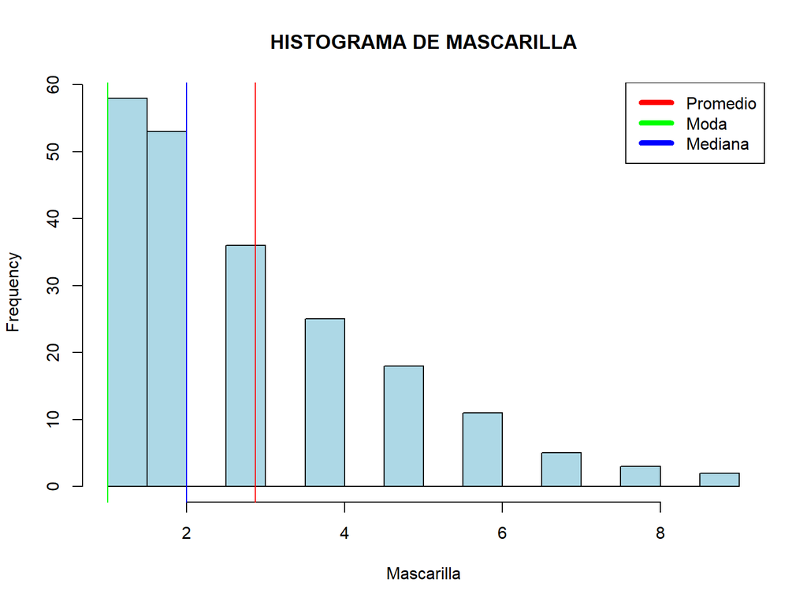

```r
hist(DDHS$Mascarilla, xlab="Mascarilla", main="HISTOGRAMA DE MASCARILLA", breaks=15, col="light blue")
abline(v=mean(DDHS$Mascarilla),col="red")
abline(v=mfv(DDHS$Mascarilla),col="green")
abline(v=median(DDHS$Mascarilla),col="blue")
legend("topright", c("Promedio", "Moda","Mediana"), col=c("red", "green", "blue"), lty=1:1, lwd=5)
```

```r
round(mean(DDHS$Mascarilla),2)
```

```
## [1] 2.87
```

```r
mfv(DDHS$Mascarilla)
```

```
## [1] 1
```

```r
median(DDHS$Mascarilla)
```

```
## [1] 2
```

Ahora si consideramos con datos atípicos:

```r
round(mean(DDHS$Mascarilla[!DDHS$Mascarilla%in% boxplot.stats(DDHS$Mascarilla)$out],na.rm=T),2)
```

```
## [1] 2.81
```

**Dispensadores**

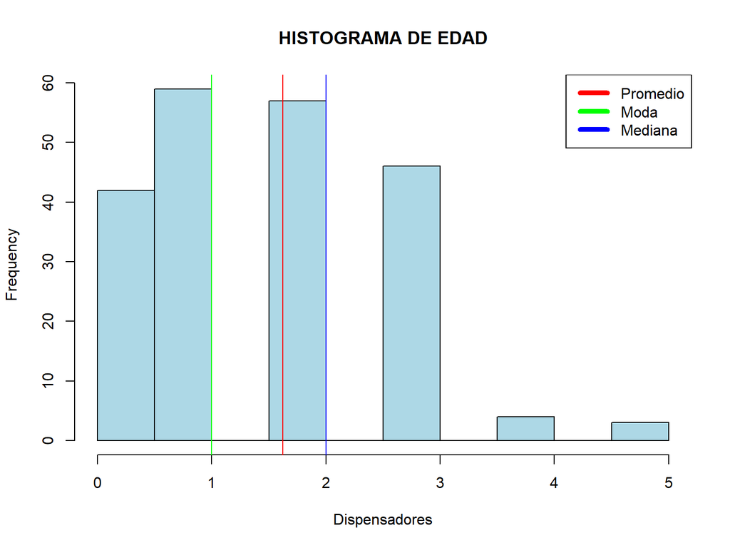

```r
hist(DDHS$Dispensadores, xlab="Dispensadores", main="HISTOGRAMA DE EDAD",breaks=15,col="light blue")
abline(v=mean(DDHS$Dispensadores),col="red")
abline(v=mfv(DDHS$Dispensadores),col="green")
abline(v=median(DDHS$Dispensadores),col="blue")
legend("topright",c("Promedio","Moda","Mediana"),col=c("red","green","blue"),lty=1:1,lwd = 5)
```

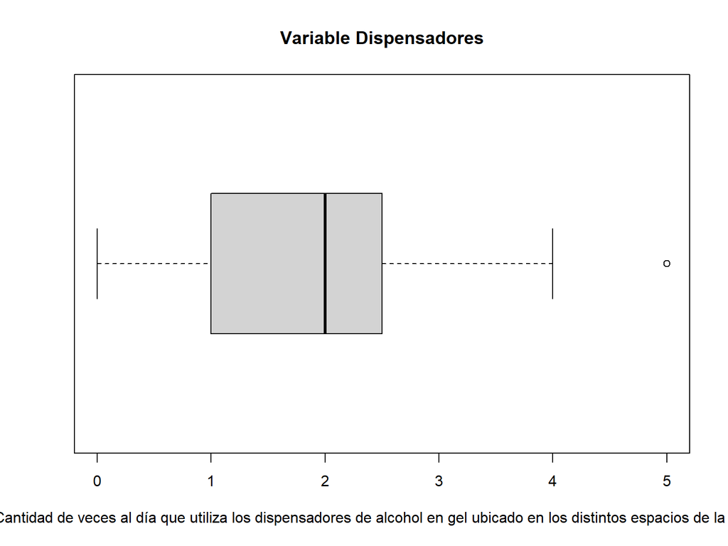

```r
boxplot(DDHS$Dispensadores
        , main = "Variable Dispensadores"
        , xlab = "Cantidad de veces al día que utiliza los dispensadores de alcohol en gel ubicado en los distintos espacios de la UTEC"
        , horizontal = TRUE
        )
```

```r
table(DDHS$Dispensadores)
```

```
##
##  0  1  2  3  4  5
## 42 59 57 46  4  3
```

```r
round(mean(DDHS$Dispensadores),2)
```

```
## [1] 1.62
```

```r
mfv(DDHS$Dispensadores)
```

```
## [1] 1
```

```r
median(DDHS$Dispensadores)
```

```
## [1] 2
```

Ahora si consideramos con datos atípicos:

```r
round(mean(DDHS$Dispensadores[!DDHS$Dispensadores%in% boxplot.stats(DDHS$Dispensadores)$out],na.rm=T),2)
```

```
## [1] 1.57
```

**Num_covid** Boxplot

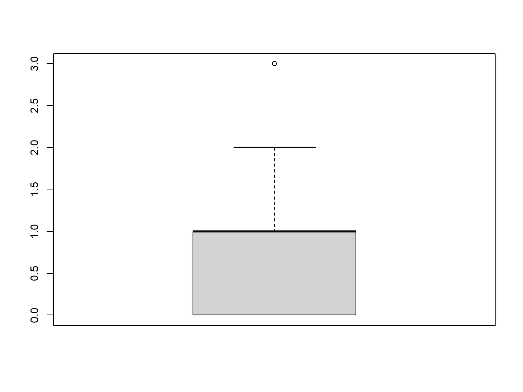

```r
boxplot(DDHS$Num_covid)
```

```r
table(DDHS$Num_covid)
```

```
##
##   0   1   2   3
## 102  66  40   3
```

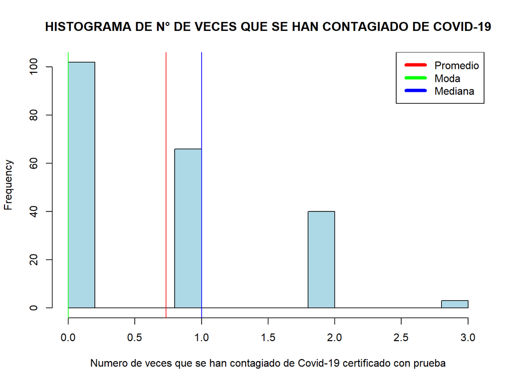

```r
hist(DDHS$Num_covid, xlab="Numero de veces que se han contagiado de Covid-19 certificado con prueba", main="HISTOGRAMA DE N° DE VECES QUE SE HAN CONTAGIADO DE COVID-19",breaks=15,col="light blue")
abline(v=mean(DDHS$Num_covid),col="red")
abline(v=mfv(DDHS$Num_covid),col="green")
abline(v=median(DDHS$Num_covid),col="blue")
legend("topright",c("Promedio","Moda","Mediana"),col=c("red","green","blue"),lty=1:1,lwd = 5)
```

```r
round(mean(DDHS$Num_covid),2)
```

```
## [1] 0.73
```

```r
mfv(DDHS$Num_covid)
```

```
## [1] 0
```

```r
median(DDHS$Num_covid)
```

```
## [1] 1
```

Ahora si consideramos con datos atípicos:

```r
round(mean(DDHS$Num_covid[!DDHS$Num_covid%in% boxplot.stats(DDHS$Num_covid)$out],na.rm=T),2)
```

```
## [1] 0.7
```

**Num_medidas** Boxplot

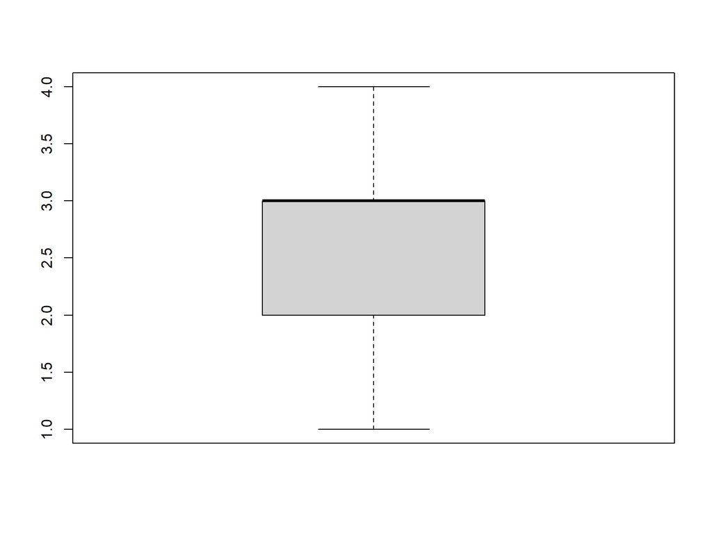

```r
boxplot(DDHS$Num_medidas)
```

```r
table(DDHS$Num_medidas)
```

```
##
##   1   2   3   4
##  12  79 119   1
```

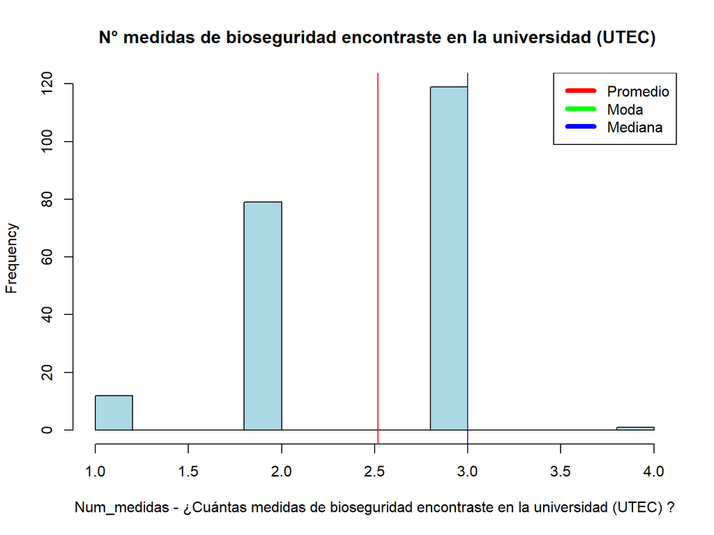

```r
hist(DDHS$Num_medidas, xlab="Num_medidas - ¿Cuántas medidas de bioseguridad encontraste en la universidad (UTEC) ?", main=" N° medidas de bioseguridad encontraste en la universidad (UTEC)",breaks=15,col="light blue")
abline(v=mean(DDHS$Num_medidas),col="red")
abline(v=mfv(DDHS$Num_medidas),col="green")
abline(v=median(DDHS$Num_medidas),col="blue")
legend("topright",c("Promedio","Moda","Mediana"),col=c("red","green","blue"),lty=1:1,lwd = 5)
```

```r
round(mean(DDHS$Num_medidas),2)
```

```
## [1] 2.52
```

```r
mfv(DDHS$Num_medidas)
```

```
## [1] 3
```

```r
median(DDHS$Num_medidas)
```

```
## [1] 3
```

Ahora si consideramos con datos atípicos:

```r
round(mean(DDHS$Num_medidas[!DDHS$Num_medidas%in% boxplot.stats(DDHS$Num_medidas)$out],na.rm=T),2)
```

```
## [1] 2.52
```

# Descriptores Gráficos y Numéricos para dos variables

### Numerica-Categórica

**Quitarte vs Dosis**

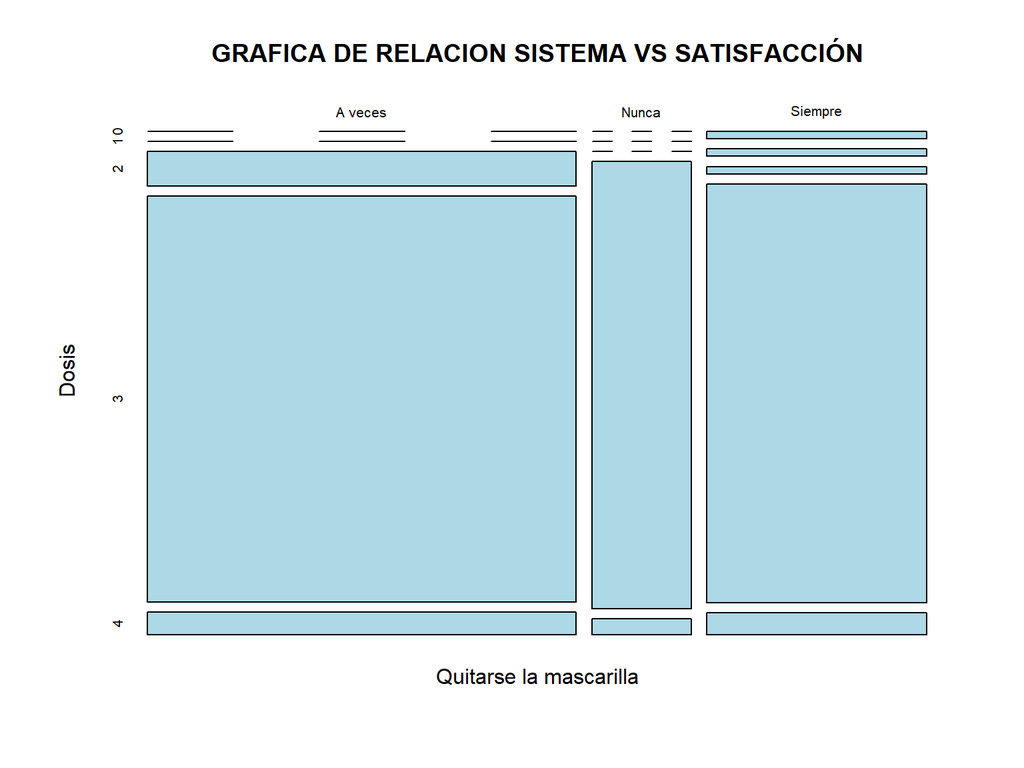

```r
mosaicplot(DDHS$Quitarte~DDHS$Dosis, xlab = "Quitarse la mascarilla", ylab = "Dosis", main = "GRAFICA DE RELACION SISTEMA VS SATISFACCIÓN", col = "light blue")
```

**Num_medidas vs Riesgo**

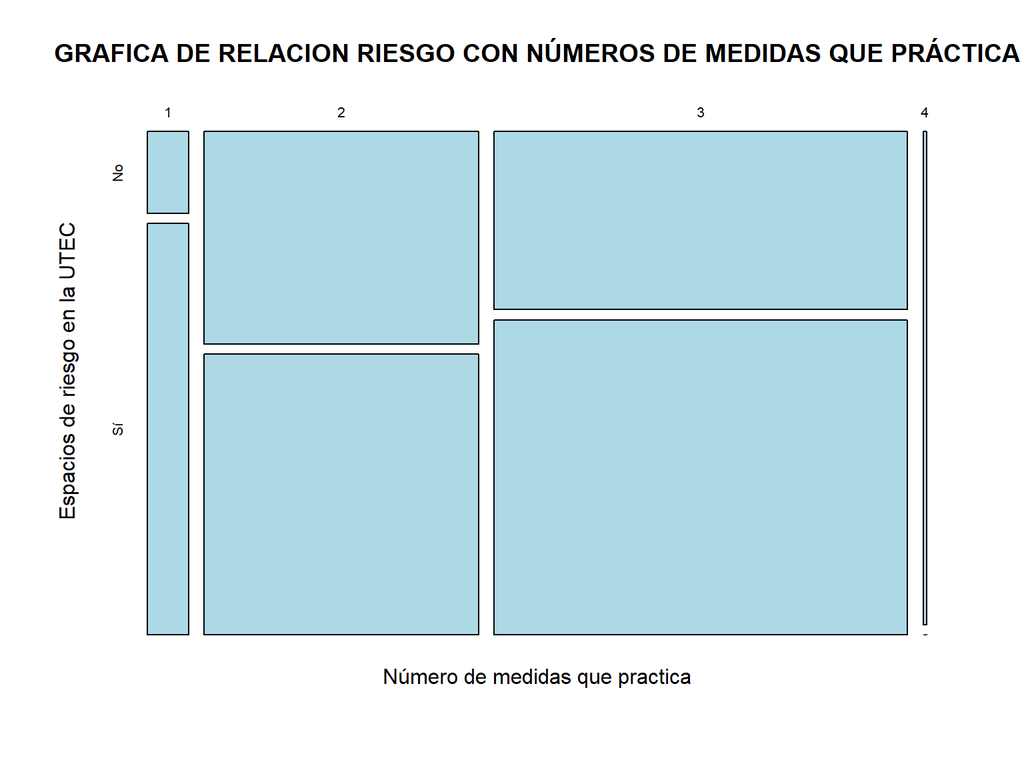

```r
mosaicplot(DDHS$Num_medidas~DDHS$Riesgo, xlab = "Número de medidas que practica", ylab = "Espacios de riesgo en la UTEC", main = "GRAFICA DE RELACION RIESGO CON NÚMEROS DE MEDIDAS QUE PRÁCTICA", col = "light blue")
```

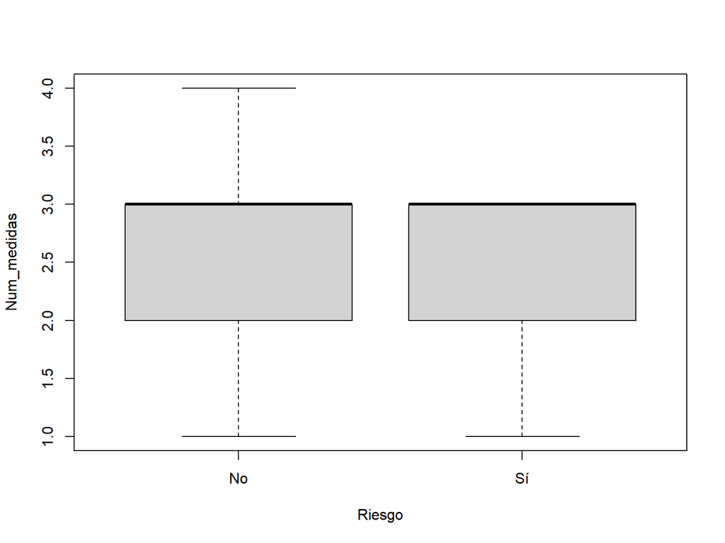

```r
with(DDHS, boxplot(Num_medidas ~ Riesgo))
```

Los Alumnos de UTEC que refirieron que “Sí” consideran que hay espacio de contagio dentro de la universidad son los que practican entre 2 o 3 medidas de prevención, lo que significa que les preocupa mantener un ambiente seguro estudiantil.

### Numérica-Numérica

**Edad Vs Dosis**

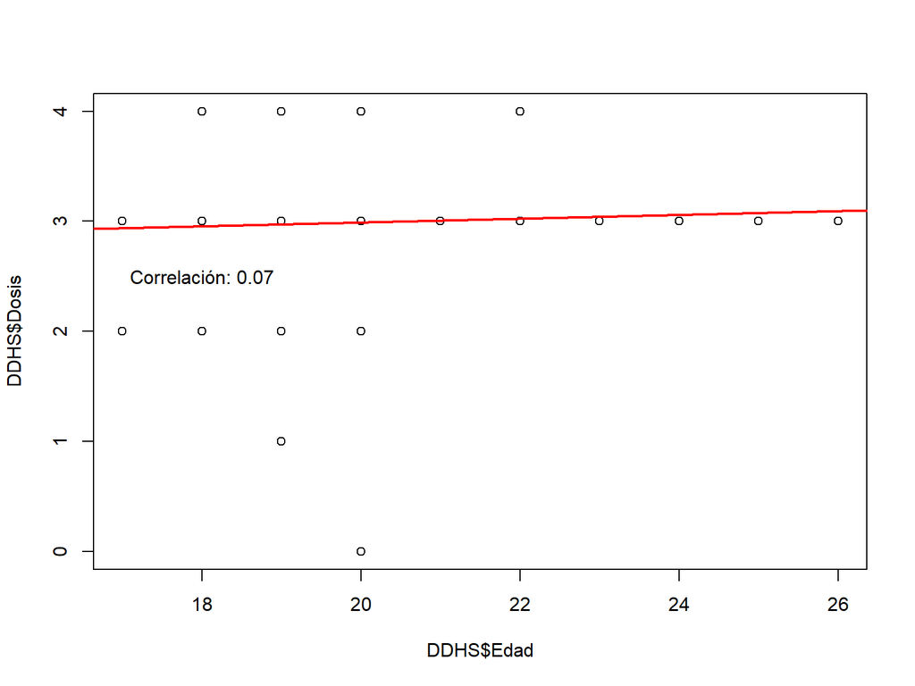

```r
plot(DDHS$Edad, DDHS$Dosis)
# Línea de regresión

model1 <-lm(DDHS$Dosis~ DDHS$Edad)
abline(model1,col="red" , lwd=2)

# Correlación de Pearson
text(paste("Correlación:", round(cor(DDHS$Edad, DDHS$Dosis), 2)), x = 18, y = 2.5)
```

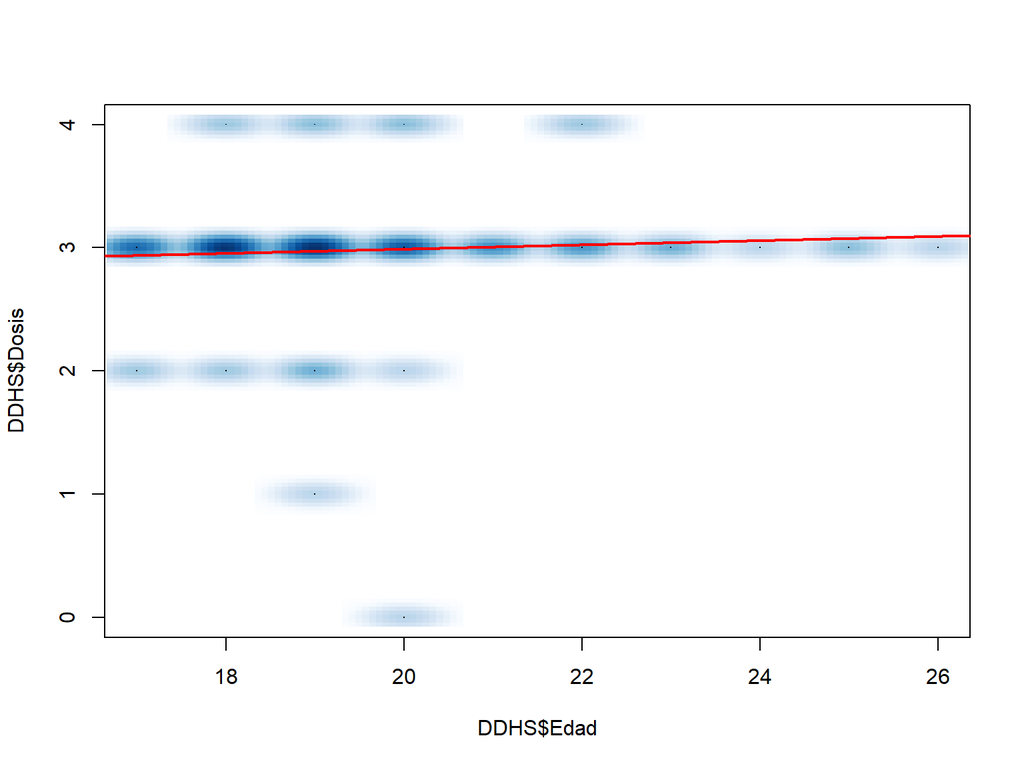

```r
smoothScatter(DDHS$Dosis~ DDHS$Edad)
abline(model1, col="red", lwd=2)
```

```r
summary(model1)
```

```
##
## Call:
## lm(formula = DDHS$Dosis ~ DDHS$Edad)
##
## Residuals:
##      Min       1Q   Median       3Q      Max
## -2.99024  0.00976  0.02666  0.04356  1.04356
##
## Coefficients:
##             Estimate Std. Error t value Pr(>|t|)
## (Intercept)  2.65229    0.31497   8.421 5.97e-15 ***
## DDHS$Edad    0.01690    0.01636   1.033    0.303
## ---
## Signif. codes:  0 '***' 0.001 '**' 0.01 '*' 0.05 '.' 0.1 ' ' 1
##
## Residual standard error: 0.3956 on 209 degrees of freedom
## Multiple R-squared:  0.005076,   Adjusted R-squared:  0.0003152
## F-statistic: 1.066 on 1 and 209 DF,  p-value: 0.303
```

Se aprecia una linea en nuestro gráfico, esta se forma por los siguientes parámetros por ejemplo el intercepto, el termino independiente, es así que nosotros podemos estimar un aproximado, en este caso nuestra correlación es débil pues es un valor cercano a cero.

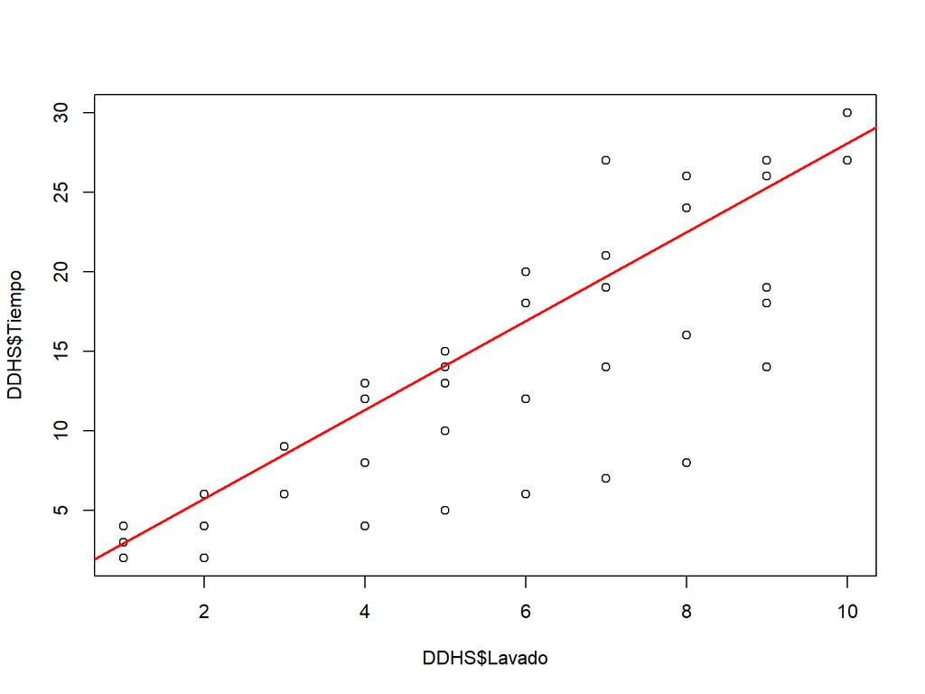

```r
plot(DDHS$Lavado, DDHS$Tiempo)
# Línea de regresión

model2 <-lm(DDHS$Tiempo~ DDHS$Lavado)
abline(model2,col="red" , lwd=2)

# Correlación de Pearson
text(paste("Correlación:", round(cor(DDHS$Lavado, DDHS$Tiempo), 2)), x = 18, y = 2.5)
```

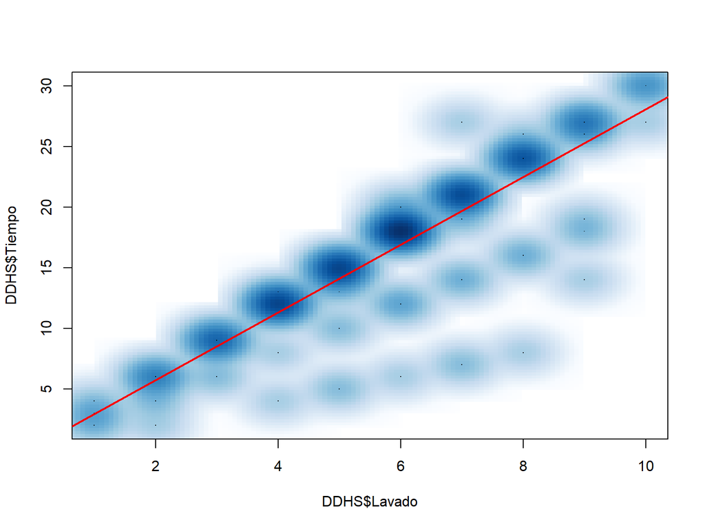

```r
smoothScatter(DDHS$Tiempo~ DDHS$Lavado)
abline(model2, col="red", lwd=2)
```

```r
summary(model1)
```

```
##
## Call:
## lm(formula = DDHS$Dosis ~ DDHS$Edad)
##
## Residuals:
##      Min       1Q   Median       3Q      Max
## -2.99024  0.00976  0.02666  0.04356  1.04356
##
## Coefficients:
##             Estimate Std. Error t value Pr(>|t|)
## (Intercept)  2.65229    0.31497   8.421 5.97e-15 ***
## DDHS$Edad    0.01690    0.01636   1.033    0.303
## ---
## Signif. codes:  0 '***' 0.001 '**' 0.01 '*' 0.05 '.' 0.1 ' ' 1
##
## Residual standard error: 0.3956 on 209 degrees of freedom
## Multiple R-squared:  0.005076,   Adjusted R-squared:  0.0003152
## F-statistic: 1.066 on 1 and 209 DF,  p-value: 0.303
```

En nuestro gráfico se aprecia una correlación *FUERTE POSITIVA*, esto nos sirve para poder estimar los valores de Tiempo que depende de lavado, pues tenemos parámetros de nuestra linea como el intercepto y termino independiente.

#Variable Aleatoria

##Bernoulli

Usaremos la variable “Riesgo” la cual refiere si los estudiantes de la Utec, consideran que hay o no espacios de de contagio dentro del campus.

Definimos la variable aleatoria X: Entonces:
$$\mathbb{X}\sim\mathsf{Ber}(p)$$

```r
bernoulli <- gsub("Sí",1, DDHS$Riesgo)
bernoulli2<- gsub("No",0, bernoulli)
s<-sum(as.numeric(bernoulli2))
n<-nrow(DDHS)
probabilidad=(s/n)
table(bernoulli2)
```

```
## bernoulli2
##   0   1
##  80 131
```

Éxito:
$$(\mathbb{X}=1)si
\hspace{0.1cm}el\hspace{0.1cm}alumno\hspace{0.1cm}considera\hspace{0.1cm}espacios\hspace{0.1cm}de\hspace{0.1cm}riesgos$$
Fracaso
$$(\mathbb{X}=0)si
\hspace{0.1cm}el\hspace{0.1cm}alumno\hspace{0.1cm}no\hspace{0.1cm}considera\hspace{0.1cm}espacios\hspace{0.1cm}de\hspace{0.1cm}riesgos$$

¿Cuál es la probabilidad que los alumnos encuestados consideren que existe espacios de riesgo dentro de la UTEC?

```r
probabilidad
```

```
## [1] 0.6208531
```

¿Cuál es la probabilidad que los alumnos encuestados consideren que no existen expacios de riesgo dentro de la utec?

```r
1-probabilidad
```

```
## [1] 0.3791469
```

##Binomial Si conocemos la probabilidad del número de éxitos en una secuencia *n* ensayos de Bernoulli con una probabilidad *p* fija entre sí. Decidimos aplicar esta función para la variable *Riesgo* del cual ya tenemos su bernoulli.

Parámetros:
$$\mathbb{Y}\sim\mathsf{Bin}(p,n)$$

$$\quad \begin{align} &n = Tamaño
\hspace{0.1cm}de\hspace{0.1cm} la \hspace{0.1cm}muestra=211 \\& p =
Probabilidad\hspace{0.1cm} de
\hspace{0.1cm}exito=0.62\qquad\end{align}$$
$$Rango(\mathbb{Y})={0,1,2,\ldots ,
211}$$

Ejemplo1: En una Encuesta a una muestra de 211 estudiantes de la UTEC, respecto si consideran que existe espacios de riesgo, existe una probabilidad de que el 37.9% delos estudiantes consideren que no. ¿Cuál es el porcentaje de probabilidad de que 131 de los encuestados seleccionados al azar señalen que sí?

```r
sí <- 1-0.379

probabilidad <-dbinom(131,211,sí)
probabilidad
```

```
## [1] 0.05653395
```

```r
porcentaje<-probabilidad*100
porcentaje
```

```
## [1] 5.653395
```

Función de probabilidad:

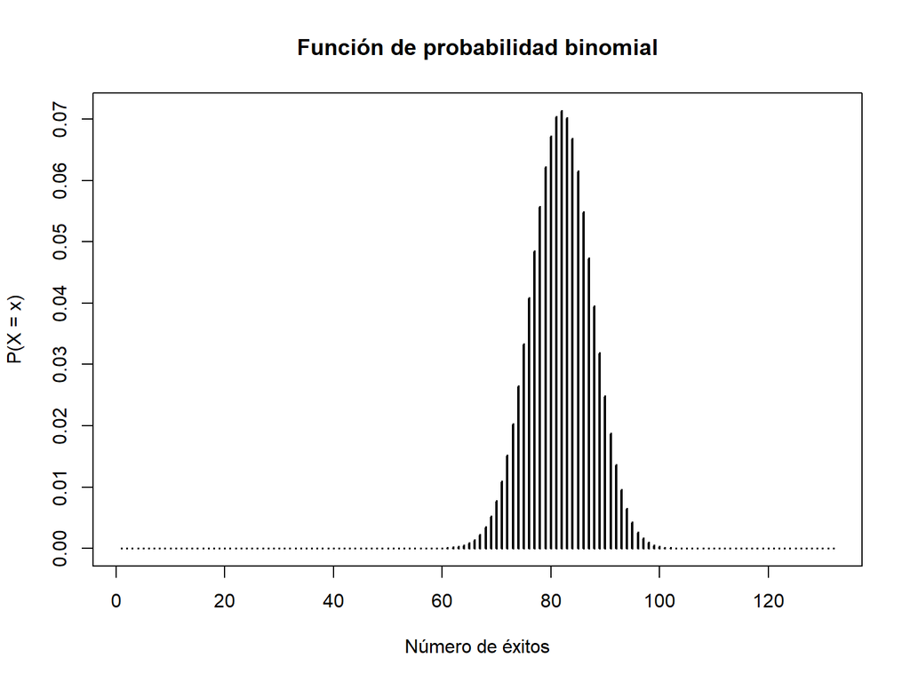

```r
plot(dbinom(1:132, size = 132, prob =0.62 ), type = "h", lwd = 2,
     main = "Función de probabilidad binomial",
     ylab = "P(X = x)", xlab = "Número de éxitos")
```

Ejemplo 2: De la misma muestra cual es la probabilidad que menos de 150 estudiantes mencionen que si existen espacios de riesgo si la probabilidad de éxito por ensayo es 0.62

```r
#No debe incluir el 150
pbinom(149,211,0.62)
```

```
## [1] 0.9964499
```

Como la distribución binomial es discreta, la probabilidad acumulada lo calculamos como la suma de las correspodientes probabilidades de la función de probabilidad

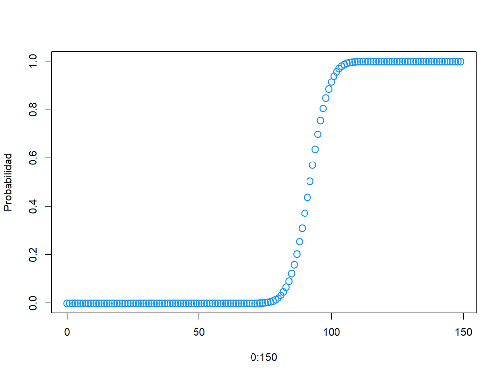

```r
plot(0:149,pbinom(0:149,149,0.62),xlab="0:150",ylab="Probabilidad",col="68",pch="O")
```

##Normal

Nuestra Variable *Tiempo* sigue una distribución Normal , ya que la gráfica de distribución es una campana de Gauss simétrica.

Gráfica de lA distribución Normal:

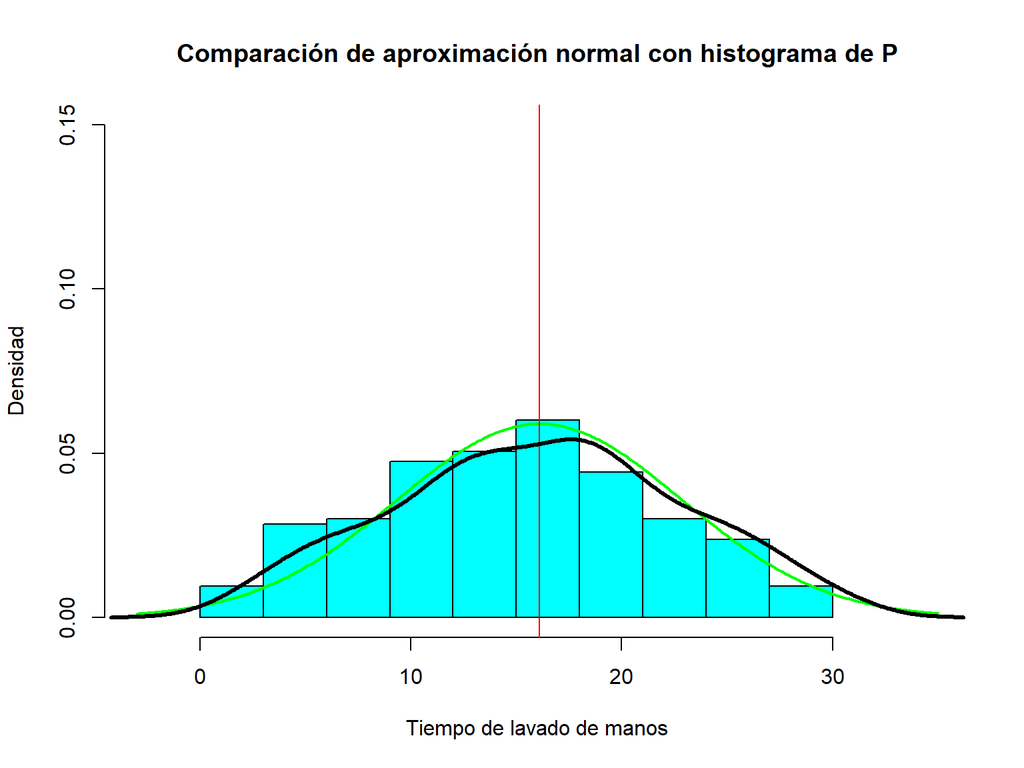

```r
P <-DDHS$Tiempo[!is.na(DDHS$Tiempo) & DDHS$Tiempo!= 0]
#des
  Mu <- mean(P)
Sigma <- sd(P)
Xs <- seq(min(P) - 5, max(P) + 5, 0.1)
Ys <- dnorm(Xs, mean=Mu, sd=Sigma) #Función de Densidad
hist(P, prob=TRUE, ylim=c(0,0.15), xlim=c(min(P) - 5, max(P) + 5),breaks=seq(0,30,3), ylab="Densidad",xlab="Tiempo de lavado de manos", main=paste("Comparación de aproximación normal con histograma de P"), col="cyan")
lines(Xs, Ys, type="l", col="green", lwd=2)#Gráfico de densidad de la normal
abline(v=mean(DDHS$Tiempo),col="red")#Linea de media
lines(density(DDHS$Tiempo), col="Black",lwd=3)#Linea de densidad
```

Parámetros:
$$X\sim\mathsf{Nor}(\mu,
\sigma)$$
$$\mu= Media=16.1$$
$$\sigma= Desviación\hspace{0.1cm}
estándar=6.77$$

```r
round(mean(DDHS$Tiempo),2)
```

```
## [1] 16.1
```

```r
median(DDHS$Tiempo)
```

```
## [1] 16
```

```r
round(sd(DDHS$Tiempo),2)
```

```
## [1] 6.77
```

*Tamaño de la Muestra*

Hallamos el tamaño de la muestra con una precisión de 0.7513
$$\mathbb{P}\left(\left|\overline{X}_n-\mu\right|\leq0.7513\right)\geq
0.2487$$

```r
sd <-sd(DDHS$Tiempo)
nivel<-0.2487
z <- qnorm((1-nivel) / 2, lower.tail = FALSE)

n1 <- (((sd)*qnorm(nivel))/z)^2
n1
```

```
## [1] 210.3146
```

La muestra que cumple esta condición es 211, justamente el tamaño de muestra de nuestro estudio.

*Intervalo de confianza*

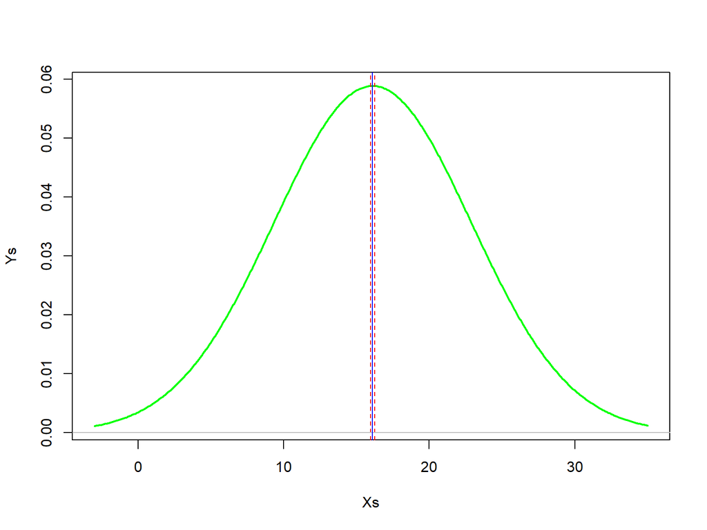

```r
sigma <-round(sd(DDHS$Tiempo),2)
n <-211
xbarra <- mean(DDHS$Tiempo)

izq <- xbarra - z*sigma/sqrt(n)

der <- xbarra + z*sigma/sqrt(n)

P <-DDHS$Tiempo[!is.na(DDHS$Tiempo) & DDHS$Tiempo!= 0]
 Mu <- mean(P)
Sigma <- sd(P)

Ys <- dnorm(Xs, mean=Mu, sd=Sigma) #Función de Densidad
plot(Xs, Ys, type="l", col="green", lwd=2)
abline(v=c(izq,der), lty = 2, col = "red")
abline(h = 0, col = "gray")
abline(v=mean(DDHS$Tiempo),col="Blue")#Linea de media
```

```r
izq
```

```
## [1] 15.95656
```

```r
der
```

```
## [1] 16.25197
```

$$15.96<u<16.25$$

```r
pnorm(15,16.23,16.73)
```

```
## [1] 0.4706959
```

Por propiedad sabemos que:
$$Si\ \ \
X\sim\mathsf{Nor}(\mu, \sigma){ \ \ } entonces {\ \ }{\displaystyle
aX+b\sim N(a\mu +b,a^{2}\sigma ^{2})}.$$

$$X\sim\mathsf{Nor}(1/2\mu\ -1/2, \
a^2\sigma^2)$$

##Poisson

Distribución

```r
P <-DDHS$Lavado[!is.na(DDHS$Lavado) & DDHS$Lavado!= 0]
#des
  Mu <- mean(P)
Sigma <- sd(P)
Xs <- seq(min(P) - 5, max(P) + 5, 0.1)
Ys <- dpois(Xs, Mu)
```

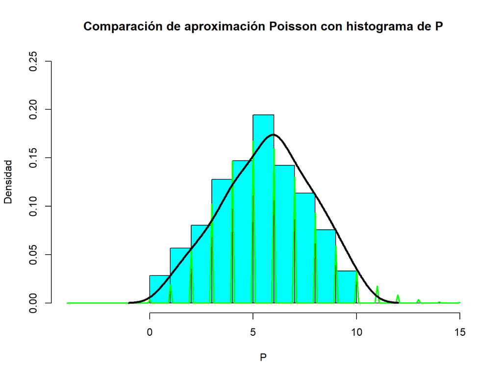

```r
hist(P, prob=TRUE, ylim=c(0, 0.25), xlim=c(min(P) - 5, max(P) + 5),breaks = seq(0,15,1), ylab="Densidad", main=paste("Comparación de aproximación Poisson con histograma de P"), col="cyan")
lines(Xs, Ys, col="green", lwd=2)
lines(density(DDHS$Lavado), col="Black",lwd=3)
```

Parámetros:

$$X\sim\mathsf{poisson}(λ)$$

```r
landa=round((mean(DDHS$Lavado)),)
landa
```

```
## [1] 6
```

Se sabe que en la encuesta respecto a la cantidad de veces que se lavan las manos por día, el promedio es 6, ¿Cuál es la probabilidad que se laven 5 veces las manos por 1 día?

$$dpois=(xo,λ)$$

```r
dpois(5,6)
```

```
## [1] 0.1606231
```

¿Cuál es la probabilidad que se laven las manos hasta 4 veces por día?

```r
ppois(4,6)
```

```
## [1] 0.2850565
```

#Conclusión

El presente trabajo fue un proyecto en el que plasmamos nuestros conocimientos es estadística y probabilidades Cuando analizamos las variables de número de medidas aplicadas y los espacios de riesgo, los Alumnos de UTEC que refirieron que “Sí” consideran que hay espacio de contagio dentro de la universidad son los que practican entre 2 o 3 medidas de prevención, lo que significa que les preocupa mantener un ambiente seguro estudiantil.